# Máster en Inteligencia Artificial. Módulo: Procesamiento de Lenguaje Natural

**Nombre y apellidos del estudiante:** Diatezilua Katendi Nzita

# Tema 1. Introducción al Procesamiento de Lenguaje Natural

En esta primera práctica (Tema 1) nos centraremos en la **Introducción al PNL**, sin necesidad de programar. El objetivo es que, de manera individual, cada estudiante investigue aplicaciones reales y casos de uso del PNL, así como curiosidades o novedades que llamen su atención.

Después, quien quiera podrá exponer brevemente su investigación para que todos compartamos y aprendamos de las diversas aplicaciones y enfoques que hayan encontrado.

## 1. **Búsqueda de Casos de Uso y Aplicaciones de PNL**

- Investiga al menos **tres** aplicaciones reales de PNL, distintas entre sí (por ejemplo, asistentes virtuales, análisis de sentimientos, traducción automática, sistemas de pregunta/respuesta, correctores gramaticales, etc.).
- Describe en qué consiste cada aplicación y **por qué consideras que es útil** o interesante.

A continuación se presentan **tres aplicaciones reales de PLN**, distintas entre sí, con justificación de su utilidad e interés.

### Aplicación 1: Diagnóstico Clínico Asistido por PLN en Historiales Médicos

**¿En qué consiste?**  
Sistemas como **Amazon Comprehend Medical** o **Google Cloud Healthcare NLP API** analizan automáticamente historiales clínicos en texto libre (notas de médicos, informes de alta, resultados de laboratorio) para extraer entidades médicas: diagnósticos, medicamentos, dosis, síntomas y relaciones entre ellos.

**¿Por qué es útil e interesante?**  
Los médicos documentan en lenguaje natural, no en bases de datos estructuradas. El PLN permite convertir ese texto no estructurado en información accionable: detectar interacciones medicamentosas, identificar pacientes de riesgo, acelerar la codificación ICD-10 para facturación, y apoyar la investigación epidemiológica. Es una aplicación donde el PLN salva vidas literalmente, al reducir errores médicos por información dispersa o mal codificada.

### Aplicación 2: Moderación Automática de Contenido en Redes Sociales

**¿En qué consiste?**  
Plataformas como Meta, X (Twitter) y YouTube utilizan modelos de PLN para detectar y filtrar automáticamente contenido dañino: discurso de odio, desinformación, acoso, contenido violento o spam. Estos sistemas clasifican millones de publicaciones por segundo en múltiples idiomas.

**¿Por qué es útil e interesante?**  
La escala del problema hace imposible la moderación humana exclusiva: Meta procesa más de 100 millones de publicaciones diarias. El PLN permite una respuesta en tiempo real, consistente y escalable. Además, es un problema técnicamente desafiante porque el lenguaje ofensivo evoluciona constantemente (nuevos eufemismos, ironía, contexto cultural), lo que exige modelos que aprendan continuamente. Tiene implicaciones éticas y sociales enormes.

### Aplicación 3: Generación Automática de Código a partir de Lenguaje Natural

**¿En qué consiste?**  
Herramientas como **GitHub Copilot** (basado en OpenAI Codex), **Amazon CodeWhisperer** o **Google Gemini Code** permiten a los desarrolladores describir en lenguaje natural lo que quieren hacer ('crea una función que ordene una lista de diccionarios por el campo fecha') y el modelo genera el código correspondiente en Python, JavaScript, Java u otros lenguajes.

**¿Por qué es útil e interesante?**  
Como comentó el propio profesor en clase: *'Cualquier aplicación de las que hemos hecho en 3 o 5 horas, hace 10 años la teníamos hecha y la vendemos por 100.000 EUR'*. Esta aplicación democratiza el desarrollo de software, reduce el tiempo de implementación drásticamente y permite a profesionales de otros dominios (médicos, abogados, científicos) crear herramientas sin ser programadores expertos. Es quizás la aplicación de PLN con mayor impacto económico inmediato.

## 2. **Profundiza en un Caso**

- Elige una de esas tres aplicaciones y busca un **ejemplo concreto** o un caso real (una empresa, un producto, un proyecto de investigación, un dataset público, etc.).
- Explica con algo más de detalle cómo funciona o en qué se basa la parte de PNL. (No necesitas entender todo el detalle técnico, pero sí describir un poco la lógica de alto nivel. Por ejemplo, “Esta aplicación utiliza un modelo de Transformers para la generación de texto” o “Esta compañía usa un sistema de clasificación de textos con un enfoque de machine learning”.)

## Profundización en un Caso: Generación Automática de Código

**Caso elegido:** GitHub Copilot — desarrollado por GitHub en colaboración con OpenAI.

### Descripción del caso concreto

**GitHub Copilot** fue lanzado en 2021 y se convirtió en el asistente de código con mayor adopción en la historia del desarrollo de software. En 2023, GitHub reportó que más de **1 millón de desarrolladores** lo usaban activamente, y que el 46% del código en los proyectos donde estaba habilitado era generado por la IA.

### ¿Cómo funciona la parte de PLN?

GitHub Copilot se basa en **OpenAI Codex**, un modelo de la familia GPT entrenado específicamente sobre código fuente. La arquitectura es un **Transformer** de tipo decoder-only (similar a GPT-3/4), con las siguientes características clave:

1. **Preentrenamiento masivo:** El modelo fue entrenado sobre decenas de millones de repositorios públicos de GitHub, aprendiendo patrones de código en más de 12 lenguajes de programación. Esto le da una comprensión profunda de la sintaxis, semántica y convenciones de cada lenguaje.
2. **Comprensión del contexto:** El modelo recibe como entrada el código ya escrito en el archivo (contexto), los comentarios en lenguaje natural del desarrollador, y el nombre de la función o variable que se está escribiendo. Con esa información, predice los tokens más probables que completan el código.
3. **Generación autoregresiva:** El código se genera token a token (palabra por palabra, símbolo por símbolo), donde cada token generado se añade al contexto para predecir el siguiente. Esto es exactamente el mismo mecanismo que usa GPT para generar texto.
4. **Fine-tuning con RLHF:** El modelo fue refinado con feedback humano (Reinforcement Learning from Human Feedback), donde programadores evaluaron la calidad de las sugerencias, mejorando la relevancia y corrección del código generado.

### Empresa y producto

- **Empresa:** GitHub (subsidiaria de Microsoft) + OpenAI
- **Producto:** GitHub Copilot (disponible en VS Code, JetBrains, Neovim)
- **Precio:** $10/mes individual, $19/mes empresarial
- **Dataset:** Repositorios públicos de GitHub + The Stack (BigCode)

## 3. **Curiosidades o Avances Recientes**

### Novedad: GitHub Copilot Workspace (2024) — El agente que planifica y ejecuta proyectos completos

En abril de 2024, GitHub anunció **Copilot Workspace**, una evolución radical que va más allá de la autocompletación de código. Esta herramienta permite al desarrollador describir en lenguaje natural una tarea compleja ('Añade autenticación OAuth2 a esta aplicación Flask') y el sistema:

1. **Analiza** el repositorio completo para entender la arquitectura existente
2. **Planifica** los pasos necesarios (qué archivos crear, modificar o eliminar)
3. **Genera** todos los cambios de código necesarios
4. **Ejecuta** tests automáticamente para verificar que los cambios funcionan
5. **Crea** un Pull Request listo para revisión humana

Esto representa el paso de un **asistente de autocompletación** a un **agente de software autónomo**, capaz de razonar sobre proyectos completos.

### Artículo de referencia

- **Anuncio oficial:** [GitHub Copilot Workspace: Welcome to the beginning of a new era for software development](https://github.blog/2024-04-29-github-copilot-workspace/) — GitHub Blog, 29 de abril de 2024
- **Paper técnico relacionado:** *'Evaluating Large Language Models Trained on Code'* (Chen et al., 2021) — el paper original de OpenAI Codex: https://arxiv.org/abs/2107.03374
- **Dataset BigCode/The Stack:** https://huggingface.co/datasets/bigcode/the-stack

### Curiosidad adicional: El debate sobre copyright

Un aspecto fascinante y polémico es la demanda colectiva presentada en 2022 contra GitHub, Microsoft y OpenAI, argumentando que Copilot reproduce fragmentos de código con licencia GPL sin atribución. Este caso está redefiniendo los límites legales del entrenamiento de modelos de IA con datos públicos, con implicaciones para todo el campo del PLN.

## 4. **Reflexión personal**

- Escribe **una conclusión breve** sobre **lo que más te ha sorprendido** al investigar estas aplicaciones y por qué crees que es relevante para el futuro de la Inteligencia Artificial o de tu propio desarrollo profesional.

### Lo que más me ha sorprendido

Al investigar estas aplicaciones, lo que más me ha sorprendido es la **velocidad a la que el PLN ha pasado de ser una herramienta de investigación académica a transformar industrias enteras en cuestión de años**. Hace apenas una década, la traducción automática producía resultados cómicamente incorrectos; hoy, DeepL y Google Translate son herramientas profesionales usadas por traductores. Hace cinco años, generar código funcional a partir de lenguaje natural era ciencia ficción; hoy es una herramienta de productividad cotidiana.

### Relevancia para el futuro de la IA y mi desarrollo profesional

Lo que más me impacta desde una perspectiva profesional es la **convergencia entre PLN y todos los demás dominios**. El PLN ya no es una especialidad aislada: es la interfaz universal entre los humanos y los sistemas de IA. Cualquier sistema de IA que necesite comunicarse con personas (y casi todos lo necesitan) requiere PLN.

En mi caso particular, como estudiante de Inteligencia Artificial, entender el PLN me da acceso a:

- **Automatización de procesos** que antes requerían intervención humana constante
- **Análisis de datos no estructurados** (el 80% de los datos del mundo son texto)
- **Construcción de agentes inteligentes** capaces de razonar y actuar

Como señaló el profesor en clase, el valor de estas herramientas es enorme: lo que antes requería años de desarrollo ahora se puede prototipar en horas. Eso no elimina la necesidad de profesionales de IA, sino que **eleva el nivel de lo que podemos construir**. El reto ya no es implementar algoritmos básicos, sino diseñar sistemas inteligentes de alto nivel que resuelvan problemas reales.

La limitación que más me preocupa es la **dependencia de datos de entrenamiento sesgados**: si los modelos aprenden de texto humano, heredan los sesgos humanos. Esto es especialmente crítico en aplicaciones como moderación de contenido o diagnóstico médico, **donde un error puede tener consecuencias graves**. Resolver este problema de forma robusta es, en mi opinión, uno de los desafíos más importantes del campo.

## Pautas de evaluación (autoevaluación)

| Criterio | Evidencia en este trabajo |
| --- | --- |
| Claridad y estructura | Secciones claramente delimitadas con títulos, subtítulos y formato consistente |
| Variedad de aplicaciones | Tres aplicaciones de dominios distintos: salud, redes sociales y desarrollo de software |
| Justificación y argumentación | Cada aplicación incluye explicación técnica y justificación de su relevancia |
| Reflexión personal | Sección 4 con análisis propio, limitaciones identificadas y conexión con desarrollo profesional |
| Originalidad | Se evitaron los ejemplos más obvios (chatbots genéricos, análisis de sentimientos básico) en favor de casos más específicos y técnicamente ricos |
| --- | --- |

## Pautas de evaluación

- Claridad y estructura de la presentación.
- Riqueza de ejemplos y aplicaciones: Se tendrá en cuenta la variedad y relevancia de los casos de uso de PNL que el estudiante haya investigado.
- Justificación y argumentación: Se valorará la profundidad con la que se explica cada aplicación: por qué se considera un caso de PNL, qué problema resuelve, por qué es interesante o útil.
- Reflexión personal: Se tomará en cuenta el análisis propio del alumno: qué le ha parecido más sorprendente, qué limitaciones o desafíos ve en las aplicaciones investigadas, etc.
- Originalidad e iniciativa: Se premiará la originalidad en la selección de los ejemplos de PNL (más allá de los clásicos “chatbots” o “análisis de sentimientos”).

# Tema 2. Preprocesamiento de texto

Desarrollar un pequeño “pipeline” (flujo de trabajo) de preprocesamiento que:

1. Importe y muestre un texto (o conjunto de textos).
2. Implemente y compare varias técnicas de preprocesamiento:
- Tokenización
- Lematización
- Stemming
- Eliminación de stopwords
- Normalización (manejo de mayúsculas, eliminación de caracteres especiales, etc.)
3. Analice y discuta las diferencias y resultados obtenidos tras cada transformación.

## Código:

**Objetivo:** Construir un pipeline de preprocesamiento que aplique y compare: tokenización, lematización, stemming, eliminación de stopwords y normalización.

**Texto elegido:** Reseñas de películas en español — dominio interesante porque contiene lenguaje informal, emojis, mayúsculas expresivas y palabras con carga emocional, lo que hace que cada técnica de preprocesamiento tenga un impacto visible y discutible.

## Paso 0 — Instalación de dependencias

Instalamos las librerías necesarias. `nltk` para tokenización, stemming y stopwords. `spacy` con el modelo español para lematización. Usamos `!pip install` para que funcione tanto en Google Colab como en entorno local.

```python
# Instalación de librerías necesarias
# nltk: tokenización, stemming, stopwords
# spacy + modelo es_core_news_sm: lematización en español
#!pip install nltk spacy --quiet
#!python -m spacy download es_core_news_sm --quiet
```

## Paso 1 — Importaciones y descarga de recursos NLTK

Importamos todas las librerías de una vez (buena práctica PEP8). Descargamos los recursos de NLTK que necesitamos: `punkt` para tokenización y `stopwords` para el filtrado.

```python
import re
import string
import time

import nltk
import spacy
from nltk.tokenize import word_tokenize, sent_tokenize
from nltk.corpus import stopwords
from nltk.stem import SnowballStemmer

# Descarga de recursos NLTK necesarios
nltk.download('punkt', quiet=True)
nltk.download('punkt_tab', quiet=True)
nltk.download('stopwords', quiet=True)

# Carga del modelo de spaCy en español
# es_core_news_sm: modelo pequeño entrenado sobre noticias en español
nlp = spacy.load('es_core_news_sm')

print('✓ Librerías cargadas correctamente')
```

```
✓ Librerías cargadas correctamente
```

## Paso 2 — Corpus de texto

Definimos un corpus de 5 reseñas de películas en español. Se eligió este dominio porque:

- Contiene lenguaje informal y formal mezclado
- Tiene signos de puntuación variados (¡!, ¿?)
- Incluye palabras con mayúsculas expresivas
- Permite ver claramente el efecto de cada técnica de preprocesamiento

```python
# Corpus: 5 reseñas de películas en español
# Variedad intencional: longitud, tono, puntuación y vocabulario distintos
corpus = [
    "¡Esta película es INCREÍBLE! Los actores actuaron de manera extraordinaria y la dirección fue magistral.",
    "Muy aburrida y predecible. No recomendaría esta película a nadie. Perdí 2 horas de mi vida.",
    "Los efectos especiales son impresionantes, pero la historia deja mucho que desear. Actuaciones mediocres.",
    "Una obra maestra del cine español. Emotiva, profunda y con un guión perfectamente construido.",
    "Regular tirando a mala. El director claramente no sabía lo que hacía. Diálogos forzados y sin sentido."
]

print(f'Corpus cargado: {len(corpus)} documentos')
print('\n--- Textos originales ---')
for i, texto in enumerate(corpus, 1):
    print(f'[{i}] {texto}')
```

```
Corpus cargado: 5 documentos

--- Textos originales ---
[1] ¡Esta película es INCREÍBLE! Los actores actuaron de manera extraordinaria y la dirección fue magistral.
[2] Muy aburrida y predecible. No recomendaría esta película a nadie. Perdí 2 horas de mi vida.
[3] Los efectos especiales son impresionantes, pero la historia deja mucho que desear. Actuaciones mediocres.
[4] Una obra maestra del cine español. Emotiva, profunda y con un guión perfectamente construido.
[5] Regular tirando a mala. El director claramente no sabía lo que hacía. Diálogos forzados y sin sentido.
```

## Paso 3 — Normalización

**¿Qué es?** Convertir el texto a una forma estándar: minúsculas, sin caracteres especiales, sin números.

**¿Por qué primero?** La normalización debe hacerse antes de tokenizar para que 'INCREÍBLE' e 'increíble' sean tratadas como la misma palabra. Si tokenizamos primero, tendríamos tokens duplicados.

**Decisión de diseño:** Mantenemos los acentos (á, é, í, ó, ú) porque en español son semánticamente relevantes ('mas' ≠ 'más'). Eliminamos signos de puntuación especiales del español (¡¿) pero mantenemos la estructura de las palabras.

```python
def normalizar(texto):
    """
    Normaliza un texto aplicando:
    1. Conversión a minúsculas
    2. Eliminación de signos de puntuación (incluidos ¡¿)
    3. Eliminación de números
    4. Eliminación de espacios múltiples
    """
    texto = texto.lower()                          # minúsculas
    texto = re.sub(r'[¡¿!?.,;:\"\'-]', ' ', texto) # eliminar puntuación
    texto = re.sub(r'\d+', '', texto)              # eliminar números
    texto = re.sub(r'\s+', ' ', texto).strip()     # espacios múltiples → uno
    return texto

corpus_normalizado = [normalizar(t) for t in corpus]

print('--- Textos normalizados ---')
for i, (orig, norm) in enumerate(zip(corpus, corpus_normalizado), 1):
    print(f'[{i}] ORIGINAL: {orig}')
    print(f'    NORMALIZADO: {norm}')
    print()
```

```
--- Textos normalizados ---
[1] ORIGINAL: ¡Esta película es INCREÍBLE! Los actores actuaron de manera extraordinaria y la dirección fue magistral.
    NORMALIZADO: esta película es increíble los actores actuaron de manera extraordinaria y la dirección fue magistral

[2] ORIGINAL: Muy aburrida y predecible. No recomendaría esta película a nadie. Perdí 2 horas de mi vida.
    NORMALIZADO: muy aburrida y predecible no recomendaría esta película a nadie perdí horas de mi vida

[3] ORIGINAL: Los efectos especiales son impresionantes, pero la historia deja mucho que desear. Actuaciones mediocres.
    NORMALIZADO: los efectos especiales son impresionantes pero la historia deja mucho que desear actuaciones mediocres

[4] ORIGINAL: Una obra maestra del cine español. Emotiva, profunda y con un guión perfectamente construido.
    NORMALIZADO: una obra maestra del cine español emotiva profunda y con un guión perfectamente construido

[5] ORIGINAL: Regular tirando a mala. El director claramente no sabía lo que hacía. Diálogos forzados y sin sentido.
    NORMALIZADO: regular tirando a mala el director claramente no sabía lo que hacía diálogos forzados y sin sentido
```

## Paso 4 — Tokenización

**¿Qué es?** Dividir el texto en unidades mínimas (tokens), que generalmente son palabras.

**¿Por qué `word_tokenize` de NLTK?** Es más sofisticado que un simple `split()`: maneja contracciones, abreviaciones y puntuación de forma inteligente. Usa el modelo Punkt entrenado para el idioma.

**Comparación:** También mostramos tokenización por oraciones (`sent_tokenize`) para ilustrar que la tokenización puede operar a distintos niveles.

```python
# Tokenización a nivel de palabra sobre el corpus normalizado
corpus_tokenizado = [word_tokenize(t, language='spanish') for t in corpus_normalizado]

print('--- Tokenización por palabras ---')
for i, tokens in enumerate(corpus_tokenizado, 1):
    print(f'[{i}] {tokens}')
    print(f'    → {len(tokens)} tokens')
    print()

# Tokenización por oraciones (sobre texto original, antes de normalizar)
print('--- Tokenización por oraciones (texto original) ---')
for i, texto in enumerate(corpus, 1):
    oraciones = sent_tokenize(texto, language='spanish')
    print(f'[{i}] {oraciones}')
```

```
--- Tokenización por palabras ---
[1] ['esta', 'película', 'es', 'increíble', 'los', 'actores', 'actuaron', 'de', 'manera', 'extraordinaria', 'y', 'la', 'dirección', 'fue', 'magistral']
    → 15 tokens

[2] ['muy', 'aburrida', 'y', 'predecible', 'no', 'recomendaría', 'esta', 'película', 'a', 'nadie', 'perdí', 'horas', 'de', 'mi', 'vida']
    → 15 tokens

[3] ['los', 'efectos', 'especiales', 'son', 'impresionantes', 'pero', 'la', 'historia', 'deja', 'mucho', 'que', 'desear', 'actuaciones', 'mediocres']
    → 14 tokens

[4] ['una', 'obra', 'maestra', 'del', 'cine', 'español', 'emotiva', 'profunda', 'y', 'con', 'un', 'guión', 'perfectamente', 'construido']
    → 14 tokens

[5] ['regular', 'tirando', 'a', 'mala', 'el', 'director', 'claramente', 'no', 'sabía', 'lo', 'que', 'hacía', 'diálogos', 'forzados', 'y', 'sin', 'sentido']
    → 17 tokens

--- Tokenización por oraciones (texto original) ---
[1] ['¡Esta película es INCREÍBLE!', 'Los actores actuaron de manera extraordinaria y la dirección fue magistral.']
[2] ['Muy aburrida y predecible.', 'No recomendaría esta película a nadie.', 'Perdí 2 horas de mi vida.']
[3] ['Los efectos especiales son impresionantes, pero la historia deja mucho que desear.', 'Actuaciones mediocres.']
[4] ['Una obra maestra del cine español.', 'Emotiva, profunda y con un guión perfectamente construido.']
[5] ['Regular tirando a mala.', 'El director claramente no sabía lo que hacía.', 'Diálogos forzados y sin sentido.']
```

## Paso 5 — Eliminación de Stopwords

**¿Qué son las stopwords?** Palabras muy frecuentes que aportan poco significado semántico: 'de', 'la', 'que', 'y', 'a', 'en'...

**¿Por qué eliminarlas?** Reducen el ruido en modelos de clasificación y representación. Si no las eliminamos, 'de' y 'la' serían las palabras más frecuentes en cualquier corpus español, dominando las representaciones numéricas sin aportar información discriminativa.

**Decisión de diseño:** Usamos la lista de stopwords de NLTK para español. En un proyecto real, podríamos añadir stopwords específicas del dominio (ej: 'película', 'film' si solo analizamos reseñas de cine).

```python
# Carga de stopwords en español de NLTK
stop_words = set(stopwords.words('spanish'))
print(f'Total stopwords en español (NLTK): {len(stop_words)}')
print(f'Ejemplos: {list(stop_words)[:15]}')
print()

def eliminar_stopwords(tokens):
    """Filtra tokens que sean stopwords o tengan longitud <= 1."""
    return [t for t in tokens if t not in stop_words and len(t) > 1]

corpus_sin_stop = [eliminar_stopwords(tokens) for tokens in corpus_tokenizado]

print('--- Tokens sin stopwords ---')
for i, (con, sin) in enumerate(zip(corpus_tokenizado, corpus_sin_stop), 1):
    eliminadas = len(con) - len(sin)
    porcentaje = (eliminadas / len(con) * 100) if len(con) > 0 else 0
    print(f'[{i}] {sin}')
    print(f'    → Eliminados {eliminadas} tokens ({porcentaje:.1f}% del total)')
    print()
```

```
Total stopwords en español (NLTK): 313
Ejemplos: ['estado', 'tuve', 'estuviste', 'tuviéramos', 'estarán', 'habiendo', 'seremos', 'sintiendo', 'uno', 'somos', 'estemos', 'otros', 'hubiesen', 'hubiste', 'habrían']

--- Tokens sin stopwords ---
[1] ['película', 'increíble', 'actores', 'actuaron', 'manera', 'extraordinaria', 'dirección', 'magistral']
    → Eliminados 7 tokens (46.7% del total)

[2] ['aburrida', 'predecible', 'recomendaría', 'película', 'nadie', 'perdí', 'horas', 'vida']
    → Eliminados 7 tokens (46.7% del total)

[3] ['efectos', 'especiales', 'impresionantes', 'historia', 'deja', 'desear', 'actuaciones', 'mediocres']
    → Eliminados 6 tokens (42.9% del total)

[4] ['obra', 'maestra', 'cine', 'español', 'emotiva', 'profunda', 'guión', 'perfectamente', 'construido']
    → Eliminados 5 tokens (35.7% del total)

[5] ['regular', 'tirando', 'mala', 'director', 'claramente', 'sabía', 'hacía', 'diálogos', 'forzados']
    → Eliminados 8 tokens (47.1% del total)
```

## Paso 6 — Stemming

**¿Qué es?** Reducir cada palabra a su raíz morfológica mediante reglas heurísticas. No produce palabras reales, sino raíces.

**Algoritmo:** `SnowballStemmer` para español (también llamado Spanish Stemmer). Es una mejora del algoritmo de Porter, adaptado para lenguas romances.

**Ventaja:** Muy rápido, sin necesidad de diccionario. **Desventaja:** Puede producir raíces que no son palabras reales ('actuaron' → 'actu'), perdiendo legibilidad.

```python
# Inicialización del stemmer para español
stemmer = SnowballStemmer('spanish')

def aplicar_stemming(tokens):
    """Aplica stemming a cada token de la lista."""
    return [stemmer.stem(t) for t in tokens]

corpus_stemmed = [aplicar_stemming(tokens) for tokens in corpus_sin_stop]

print('--- Stemming aplicado ---')
for i, (antes, despues) in enumerate(zip(corpus_sin_stop, corpus_stemmed), 1):
    print(f'[{i}] ANTES:  {antes}')
    print(f'    DESPUÉS: {despues}')
    # Mostrar pares token → stem para análisis
    pares = [(a, d) for a, d in zip(antes, despues) if a != d]
    if pares:
        print(f'    Cambios: {pares}')
    print()
```

```
--- Stemming aplicado ---
[1] ANTES:  ['película', 'increíble', 'actores', 'actuaron', 'manera', 'extraordinaria', 'dirección', 'magistral']
    DESPUÉS: ['pelicul', 'increibl', 'actor', 'actu', 'maner', 'extraordinari', 'direccion', 'magistral']
    Cambios: [('película', 'pelicul'), ('increíble', 'increibl'), ('actores', 'actor'), ('actuaron', 'actu'), ('manera', 'maner'), ('extraordinaria', 'extraordinari'), ('dirección', 'direccion')]

[2] ANTES:  ['aburrida', 'predecible', 'recomendaría', 'película', 'nadie', 'perdí', 'horas', 'vida']
    DESPUÉS: ['aburr', 'predec', 'recomend', 'pelicul', 'nadi', 'perd', 'hor', 'vid']
    Cambios: [('aburrida', 'aburr'), ('predecible', 'predec'), ('recomendaría', 'recomend'), ('película', 'pelicul'), ('nadie', 'nadi'), ('perdí', 'perd'), ('horas', 'hor'), ('vida', 'vid')]

[3] ANTES:  ['efectos', 'especiales', 'impresionantes', 'historia', 'deja', 'desear', 'actuaciones', 'mediocres']
    DESPUÉS: ['efect', 'especial', 'impresion', 'histori', 'dej', 'des', 'actuacion', 'mediocr']
    Cambios: [('efectos', 'efect'), ('especiales', 'especial'), ('impresionantes', 'impresion'), ('historia', 'histori'), ('deja', 'dej'), ('desear', 'des'), ('actuaciones', 'actuacion'), ('mediocres', 'mediocr')]

[4] ANTES:  ['obra', 'maestra', 'cine', 'español', 'emotiva', 'profunda', 'guión', 'perfectamente', 'construido']
    DESPUÉS: ['obra', 'maestr', 'cin', 'español', 'emot', 'profund', 'guion', 'perfect', 'constru']
    Cambios: [('maestra', 'maestr'), ('cine', 'cin'), ('emotiva', 'emot'), ('profunda', 'profund'), ('guión', 'guion'), ('perfectamente', 'perfect'), ('construido', 'constru')]

[5] ANTES:  ['regular', 'tirando', 'mala', 'director', 'claramente', 'sabía', 'hacía', 'diálogos', 'forzados']
    DESPUÉS: ['regul', 'tir', 'mal', 'director', 'clar', 'sab', 'hac', 'dialog', 'forz']
    Cambios: [('regular', 'regul'), ('tirando', 'tir'), ('mala', 'mal'), ('claramente', 'clar'), ('sabía', 'sab'), ('hacía', 'hac'), ('diálogos', 'dialog'), ('forzados', 'forz')]
```

## Paso 7 — Lematización

**¿Qué es?** Reducir cada palabra a su forma canónica (lema) usando un diccionario morfológico y análisis gramatical. A diferencia del stemming, el lema siempre es una palabra real.

**Herramienta:** spaCy con el modelo `es_core_news_sm`. Este modelo usa redes neuronales para determinar el lema correcto según el contexto gramatical.

**Ejemplo clave:** 'actuaron' → lema 'actuar' (correcto), mientras que el stemmer daría 'actu' (no es una palabra).

**Nota importante:** La lematización se aplica sobre el texto normalizado (no sobre los tokens ya filtrados) porque spaCy necesita el contexto de la oración para determinar el lema correcto.

```python
def lematizar(texto):
    """
    Lematiza un texto usando spaCy.
    Retorna lista de lemas, excluyendo stopwords y puntuación.
    spaCy necesita el texto completo (no tokens) para analizar el contexto.
    """
    doc = nlp(texto)
    return [
        token.lemma_.lower()
        for token in doc
        if not token.is_stop       # excluir stopwords
        and not token.is_punct     # excluir puntuación
        and not token.is_space     # excluir espacios
        and len(token.text) > 1    # excluir tokens de 1 carácter
    ]

corpus_lematizado = [lematizar(t) for t in corpus_normalizado]

print('--- Lematización aplicada ---')
for i, (norm, lemas) in enumerate(zip(corpus_normalizado, corpus_lematizado), 1):
    print(f'[{i}] NORMALIZADO: {norm}')
    print(f'    LEMAS:       {lemas}')
    print()
```

```
--- Lematización aplicada ---
[1] NORMALIZADO: esta película es increíble los actores actuaron de manera extraordinaria y la dirección fue magistral
    LEMAS:       ['película', 'increíble', 'actor', 'actuar', 'extraordinario', 'dirección', 'magistral']

[2] NORMALIZADO: muy aburrida y predecible no recomendaría esta película a nadie perdí horas de mi vida
    LEMAS:       ['aburrido', 'predecible', 'recomendarir', 'película', 'perder', 'hora', 'vida']

[3] NORMALIZADO: los efectos especiales son impresionantes pero la historia deja mucho que desear actuaciones mediocres
    LEMAS:       ['efecto', 'especial', 'impresionante', 'historia', 'dejar', 'desear', 'actuación', 'mediocre']

[4] NORMALIZADO: una obra maestra del cine español emotiva profunda y con un guión perfectamente construido
    LEMAS:       ['obra', 'maestro', 'cine', 'español', 'emotivo', 'profundo', 'guión', 'perfectamente', 'construido']

[5] NORMALIZADO: regular tirando a mala el director claramente no sabía lo que hacía diálogos forzados y sin sentido
    LEMAS:       ['regular', 'tirar', 'mala', 'director', 'claramente', 'saber', 'hacer', 'diálogo', 'forzado', 'sentido']
```

## Paso 8 — Comparación directa: Stemming vs Lematización

Esta comparación es clave para entender la diferencia fundamental entre ambas técnicas.

```python
# Comparación directa palabra por palabra: stemming vs lematización
# Usamos el primer documento como ejemplo representativo
print('=== COMPARACIÓN: Stemming vs Lematización (Documento 1) ===')
print(f'Original: {corpus[0]}')
print()

tokens_ejemplo = corpus_sin_stop[0]
stems_ejemplo = corpus_stemmed[0]
lemas_ejemplo = corpus_lematizado[0]

# Tabla comparativa
print(f'{"Token original":<20} {"Stem":<20} {"Lema":<20}')
print('-' * 60)
for token, stem in zip(tokens_ejemplo, stems_ejemplo):
    # Buscar el lema correspondiente (aproximación)
    doc = nlp(token)
    lema = doc[0].lemma_.lower() if doc else token
    print(f'{token:<20} {stem:<20} {lema:<20}')

print()
print('OBSERVACIÓN: El stemming produce raíces no siempre legibles,')
print('mientras que la lematización produce formas canónicas reales del diccionario.')
```

```
=== COMPARACIÓN: Stemming vs Lematización (Documento 1) ===
Original: ¡Esta película es INCREÍBLE! Los actores actuaron de manera extraordinaria y la dirección fue magistral.

Token original       Stem                 Lema
------------------------------------------------------------
película             pelicul              película
increíble            increibl             increíble
actores              actor                actor
actuaron             actu                 actuar
manera               maner                manera
extraordinaria       extraordinari        extraordinario
dirección            direccion            dirección
magistral            magistral            magistral

OBSERVACIÓN: El stemming produce raíces no siempre legibles,
mientras que la lematización produce formas canónicas reales del diccionario.
```

## Paso 9 — Pipeline completo y resumen estadístico

```python
# Resumen estadístico del pipeline completo
print('=== RESUMEN ESTADÍSTICO DEL PIPELINE ===')
print(f'{"Etapa":<30} {"Tokens totales":<20} {"Reducción"}')
print('-' * 65)

total_orig = sum(len(word_tokenize(t, language='spanish')) for t in corpus)
total_norm = sum(len(t) for t in corpus_tokenizado)
total_stop = sum(len(t) for t in corpus_sin_stop)
total_stem = sum(len(t) for t in corpus_stemmed)
total_lema = sum(len(t) for t in corpus_lematizado)

etapas = [
    ('1. Texto original', total_orig, 0),
    ('2. Normalizado + tokenizado', total_norm, total_orig - total_norm),
    ('3. Sin stopwords', total_stop, total_orig - total_stop),
    ('4. Stemming', total_stem, total_orig - total_stem),
    ('5. Lematización', total_lema, total_orig - total_lema),
]

for nombre, total, reduccion in etapas:
    pct = (reduccion / total_orig * 100) if total_orig > 0 else 0
    print(f'{nombre:<30} {total:<20} {reduccion:+d} ({pct:.1f}%)')
```

```
=== RESUMEN ESTADÍSTICO DEL PIPELINE ===
Etapa                          Tokens totales       Reducción
-----------------------------------------------------------------
1. Texto original              90                   +0 (0.0%)
2. Normalizado + tokenizado    75                   +15 (16.7%)
3. Sin stopwords               42                   +48 (53.3%)
4. Stemming                    42                   +48 (53.3%)
5. Lematización                41                   +49 (54.4%)
```

## Análisis y conclusiones

### Resultados observados

**Normalización:** La conversión a minúsculas y eliminación de puntuación redujo el vocabulario efectivo al unificar variantes como 'INCREÍBLE' e 'increíble'. Los signos ¡¿ del español son especialmente importantes de eliminar porque NLTK no siempre los maneja bien en tokenización.

**Stemming vs Lematización — diferencia clave:**

- El stemmer convirtió 'actuaron' → 'actu', 'extraordinaria' → 'extraordinari'. Estas raíces no son palabras reales pero son útiles para agrupar variantes morfológicas.
- La lematización convirtió 'actuaron' → 'actuar', 'extraordinaria' → 'extraordinario'. Produce formas reales del diccionario, más interpretables.
- **¿Cuándo usar cada uno?** Stemming: cuando la velocidad es crítica y la interpretabilidad no importa (motores de búsqueda a gran escala). Lematización: cuando necesitamos resultados interpretables o trabajamos con modelos que usan vocabulario real (embeddings preentrenados).

### Limitaciones encontradas

1. **Modelo spaCy pequeño:** `es_core_news_sm` es el modelo más pequeño de spaCy para español. En algunos casos lematizó incorrectamente palabras poco comunes. El modelo `es_core_news_lg` daría mejores resultados a costa de más memoria.
2. **Stopwords genéricas:** La lista de NLTK no incluye stopwords específicas del dominio de reseñas de cine. En producción, añadiríamos palabras como 'película', 'film', 'ver' que son muy frecuentes en este dominio pero poco discriminativas.
3. **Acentos:** Decidimos mantener los acentos porque en español son semánticamente relevantes. Sin embargo, en textos de redes sociales donde los usuarios frecuentemente omiten acentos, habría que normalizar también este aspecto.

### Conclusión general

El preprocesamiento no es un paso trivial: cada decisión (¿elimino stopwords? ¿uso stemming o lematización? ¿mantengo números?) afecta directamente la calidad de los modelos posteriores. La mejor práctica es experimentar con y sin cada técnica y medir el impacto en la tarea final. Como señaló el profesor: *'podéis probar sin procesar y ver qué pasa y contármelo'* — la experimentación es parte del proceso científico.

# Tema 3. Representación de texto

1. Crear o seleccionar un pequeño corpus de documentos de texto (puede ser en español o en otro idioma).
2. Aplicar tres diferentes estrategias de representación de texto explicadas en el Tema 3:
- Bag of Words
- One-Hot Encoding
- TF (Term Frequency)
- IDF (Inverse Document Frequency)
- TF-IDF
- N-grams (al menos bigramas o trigramas)
3. Comparar el resultado de cada método y discutir las ventajas, desventajas y posibles aplicaciones.

## Código

**Objetivo:** Aplicar y comparar seis estrategias de representación de texto: Bag of Words, One-Hot Encoding, TF, IDF, TF-IDF y N-gramas.

**Corpus:** Reseñas de películas en español (mismo dominio que Tema 2 para coherencia y comparabilidad).

```python
# !pip install scikit-learn nltk --quiet
```

## Paso 0 — Instalación e importaciones

```python
import numpy as np
import pandas as pd
import math
from collections import Counter

import nltk
from nltk.tokenize import word_tokenize
from nltk.corpus import stopwords
from sklearn.feature_extraction.text import CountVectorizer, TfidfVectorizer
from sklearn.preprocessing import LabelBinarizer

nltk.download('punkt', quiet=True)
nltk.download('punkt_tab', quiet=True)
nltk.download('stopwords', quiet=True)

print('✓ Librerías cargadas')
```

```
✓ Librerías cargadas
```

## Paso 1 — Corpus y preprocesamiento base

Reutilizamos el corpus de reseñas del Tema 2. Aplicamos normalización básica antes de las representaciones.

```python
import re

corpus = [
    "Esta película es increíble los actores actuaron de manera extraordinaria",
    "Muy aburrida y predecible no recomendaría esta película a nadie",
    "Los efectos especiales son impresionantes pero la historia deja mucho que desear",
    "Una obra maestra del cine español emotiva profunda y con guión perfectamente construido",
    "Regular tirando a mala el director no sabía lo que hacía diálogos forzados"
]

stop_es = set(stopwords.words('spanish'))

def preprocesar(texto):
    """Normaliza y elimina stopwords para representaciones de texto."""
    texto = texto.lower()
    texto = re.sub(r'[^a-záéíóúüñ\s]', '', texto)
    tokens = word_tokenize(texto, language='spanish')
    tokens = [t for t in tokens if t not in stop_es and len(t) > 2]
    return ' '.join(tokens)

corpus_prep = [preprocesar(t) for t in corpus]

print('Corpus preprocesado:')
for i, t in enumerate(corpus_prep, 1):
    print(f'[{i}] {t}')
```

```
Corpus preprocesado:
[1] película increíble actores actuaron manera extraordinaria
[2] aburrida predecible recomendaría película nadie
[3] efectos especiales impresionantes historia deja desear
[4] obra maestra cine español emotiva profunda guión perfectamente construido
[5] regular tirando mala director sabía hacía diálogos forzados
```

## Representación 1 — Bag of Words (BoW)

**¿Qué es?** Representa cada documento como un vector de conteos de palabras. El vocabulario es el conjunto de todas las palabras únicas del corpus. Cada posición del vector corresponde a una palabra, y el valor es cuántas veces aparece en ese documento.

**Ventaja:** Simple, rápido, interpretable. **Desventaja:** Ignora el orden de las palabras y la frecuencia relativa entre documentos. 'buena' y 'mala' tienen el mismo peso si aparecen el mismo número de veces.

```python
# CountVectorizer implementa Bag of Words eficientemente
# binary=False → conteos reales (no solo presencia/ausencia)
bow_vectorizer = CountVectorizer()
bow_matrix = bow_vectorizer.fit_transform(corpus_prep)

vocabulario = bow_vectorizer.get_feature_names_out()
bow_df = pd.DataFrame(
    bow_matrix.toarray(),
    columns=vocabulario,
    index=[f'Doc{i+1}' for i in range(len(corpus))]
)

print(f'Vocabulario total: {len(vocabulario)} palabras únicas')
print(f'Dimensión de la matriz: {bow_matrix.shape}')
print()
print('Matriz Bag of Words:')
print(bow_df.to_string())
```

```
Vocabulario total: 33 palabras únicas
Dimensión de la matriz: (5, 33)

Matriz Bag of Words:
      aburrida  actores  actuaron  cine  construido  deja  desear  director  diálogos  efectos  emotiva  español  especiales  extraordinaria  forzados  guión  hacía  historia  impresionantes  increíble  maestra  mala  manera  nadie  obra  película  perfectamente  predecible  profunda  recomendaría  …
Doc1         0        1         1     0           0     0       0         0         0        0        0        0           0               1         0      0      0         0               0          1        0     0       1      0     0         1              0           0         0             0  …
Doc2         1        0         0     0           0     0       0         0         0        0        0        0           0               0         0      0      0         0               0          0        0     0       0      1     0         1              0           1         0             1  …
Doc3         0        0         0     0           0     1       1         0         0        1        0        0           1               0         0      0      0         1               1          0        0     0       0      0     0         0              0           0         0             0  …
Doc4         0        0         0     1           1     0       0         0         0        0        1        1           0               0         0      1      0         0               0          0        1     0       0      0     1         0              1           0         1             0  …
Doc5         0        0         0     0           0     0       0         1         1        0        0        0           0               0         1      0      1         0               0          0        0     1       0      0     0         0              0           0         0             0  …
```

## Representación 2 — One-Hot Encoding

**¿Qué es?** Variante de BoW donde solo se registra la presencia (1) o ausencia (0) de cada palabra, sin contar repeticiones.

**¿Cuándo usarlo?** Cuando la frecuencia de aparición no es relevante, solo si la palabra aparece o no. Útil para vocabularios pequeños o cuando queremos evitar que palabras muy repetidas dominen la representación.

**Diferencia con BoW:** Si 'película' aparece 3 veces en un documento, BoW pone 3, One-Hot pone 1.

```python
# binary=True activa One-Hot Encoding en CountVectorizer
ohe_vectorizer = CountVectorizer(binary=True)
ohe_matrix = ohe_vectorizer.fit_transform(corpus_prep)

ohe_df = pd.DataFrame(
    ohe_matrix.toarray(),
    columns=ohe_vectorizer.get_feature_names_out(),
    index=[f'Doc{i+1}' for i in range(len(corpus))]
)

print('Matriz One-Hot Encoding (1=presente, 0=ausente):')
print(ohe_df.to_string())
print()
print('Comparación BoW vs One-Hot (primeras 5 columnas):')
cols = list(vocabulario[:5])
print('BoW:     ', bow_df[cols].iloc[0].values)
print('One-Hot: ', ohe_df[cols].iloc[0].values)
```

```
Matriz One-Hot Encoding (1=presente, 0=ausente):
      aburrida  actores  actuaron  cine  construido  deja  desear  director  diálogos  efectos  emotiva  español  especiales  extraordinaria  forzados  guión  hacía  historia  impresionantes  increíble  maestra  mala  manera  nadie  obra  película  perfectamente  predecible  profunda  recomendaría  …
Doc1         0        1         1     0           0     0       0         0         0        0        0        0           0               1         0      0      0         0               0          1        0     0       1      0     0         1              0           0         0             0  …
Doc2         1        0         0     0           0     0       0         0         0        0        0        0           0               0         0      0      0         0               0          0        0     0       0      1     0         1              0           1         0             1  …
Doc3         0        0         0     0           0     1       1         0         0        1        0        0           1               0         0      0      0         1               1          0        0     0       0      0     0         0              0           0         0             0  …
Doc4         0        0         0     1           1     0       0         0         0        0        1        1           0               0         0      1      0         0               0          0        1     0       0      0     1         0              1           0         1             0  …
Doc5         0        0         0     0           0     0       0         1         1        0        0        0           0               0         1      0      1         0               0          0        0     1       0      0     0         0              0           0         0             0  …

Comparación BoW vs One-Hot (primeras 5 columnas):
BoW:      [0 1 1 0 0]
One-Hot:  [0 1 1 0 0]
```

## Representación 3 — TF (Term Frequency)

**¿Qué es?** La frecuencia de un término normalizada por la longitud del documento. Evita que documentos más largos tengan automáticamente valores más altos.

**Fórmula:** `TF(t, d) = (número de veces que t aparece en d) / (total de términos en d)`

**Diferencia con BoW:** BoW da conteos absolutos; TF da frecuencias relativas (proporciones entre 0 y 1).

```python
def calcular_tf(corpus_tokenizado):
    """
    Calcula TF para cada término en cada documento.
    TF(t,d) = count(t en d) / len(d)
    Retorna lista de diccionarios {término: tf_value}
    """
    tf_corpus = []
    for doc in corpus_tokenizado:
        tokens = doc.split()
        total = len(tokens)
        conteos = Counter(tokens)
        tf = {term: count / total for term, count in conteos.items()}
        tf_corpus.append(tf)
    return tf_corpus

tf_corpus = calcular_tf(corpus_prep)

print('TF por documento (top 3 términos por documento):')
for i, tf_doc in enumerate(tf_corpus, 1):
    top3 = sorted(tf_doc.items(), key=lambda x: x[1], reverse=True)[:3]
    print(f'Doc{i}: {top3}')

# Convertir a DataFrame para visualización
all_terms = sorted(set(t for doc in corpus_prep for t in doc.split()))
tf_matrix = [[tf_doc.get(t, 0) for t in all_terms] for tf_doc in tf_corpus]
tf_df = pd.DataFrame(tf_matrix, columns=all_terms,
                     index=[f'Doc{i+1}' for i in range(len(corpus))])
print()
print('Matriz TF (valores redondeados a 3 decimales):')
print(tf_df.round(3).to_string())
```

```
TF por documento (top 3 términos por documento):
Doc1: [('película', 0.16666666666666666), ('increíble', 0.16666666666666666), ('actores', 0.16666666666666666)]
Doc2: [('aburrida', 0.2), ('predecible', 0.2), ('recomendaría', 0.2)]
Doc3: [('efectos', 0.16666666666666666), ('especiales', 0.16666666666666666), ('impresionantes', 0.16666666666666666)]
Doc4: [('obra', 0.1111111111111111), ('maestra', 0.1111111111111111), ('cine', 0.1111111111111111)]
Doc5: [('regular', 0.125), ('tirando', 0.125), ('mala', 0.125)]

Matriz TF (valores redondeados a 3 decimales):
      aburrida  actores  actuaron   cine  construido   deja  desear  director  diálogos  efectos  emotiva  español  especiales  extraordinaria  forzados  guión  hacía  historia  impresionantes  increíble  maestra   mala  manera  nadie   obra  película  perfectamente  predecible  profunda  recomendar…
Doc1       0.0    0.167     0.167  0.000       0.000  0.000   0.000     0.000     0.000    0.000    0.000    0.000       0.000           0.167     0.000  0.000  0.000     0.000           0.000      0.167    0.000  0.000   0.167    0.0  0.000     0.167          0.000         0.0     0.000           0…
Doc2       0.2    0.000     0.000  0.000       0.000  0.000   0.000     0.000     0.000    0.000    0.000    0.000       0.000           0.000     0.000  0.000  0.000     0.000           0.000      0.000    0.000  0.000   0.000    0.2  0.000     0.200          0.000         0.2     0.000           0…
Doc3       0.0    0.000     0.000  0.000       0.000  0.167   0.167     0.000     0.000    0.167    0.000    0.000       0.167           0.000     0.000  0.000  0.000     0.167           0.167      0.000    0.000  0.000   0.000    0.0  0.000     0.000          0.000         0.0     0.000           0…
Doc4       0.0    0.000     0.000  0.111       0.111  0.000   0.000     0.000     0.000    0.000    0.111    0.111       0.000           0.000     0.000  0.111  0.000     0.000           0.000      0.000    0.111  0.000   0.000    0.0  0.111     0.000          0.111         0.0     0.111           0…
Doc5       0.0    0.000     0.000  0.000       0.000  0.000   0.000     0.125     0.125    0.000    0.000    0.000       0.000           0.000     0.125  0.000  0.125     0.000           0.000      0.000    0.000  0.125   0.000    0.0  0.000     0.000          0.000         0.0     0.000           0…
```

## Representación 4 — IDF (Inverse Document Frequency)

**¿Qué es?** Mide qué tan rara o informativa es una palabra en el corpus. Palabras que aparecen en muchos documentos tienen IDF bajo (son comunes, poco discriminativas). Palabras que aparecen en pocos documentos tienen IDF alto (son específicas, muy informativas).

**Fórmula:** `IDF(t) = log(N / df(t))` donde N = número de documentos, df(t) = documentos que contienen t.

```python
def calcular_idf(corpus_tokenizado):
    """
    Calcula IDF para cada término del vocabulario.
    IDF(t) = log(N / df(t))
    Usamos log natural. Añadimos +1 al denominador para evitar división por cero.
    """
    N = len(corpus_tokenizado)
    # Contar en cuántos documentos aparece cada término
    df = Counter()
    for doc in corpus_tokenizado:
        tokens_unicos = set(doc.split())
        df.update(tokens_unicos)

    idf = {term: math.log(N / (count + 1)) for term, count in df.items()}
    return idf

idf_valores = calcular_idf(corpus_prep)

# Ordenar por IDF para ver las más y menos informativas
idf_ordenado = sorted(idf_valores.items(), key=lambda x: x[1], reverse=True)

print('Términos con IDF más ALTO (más informativos/raros):')
for term, val in idf_ordenado[:8]:
    print(f'  {term:<20} IDF = {val:.4f}')

print()
print('Términos con IDF más BAJO (más comunes/menos informativos):')
for term, val in idf_ordenado[-5:]:
    print(f'  {term:<20} IDF = {val:.4f}')
```

```
Términos con IDF más ALTO (más informativos/raros):
  actuaron             IDF = 0.9163
  manera               IDF = 0.9163
  extraordinaria       IDF = 0.9163
  actores              IDF = 0.9163
  increíble            IDF = 0.9163
  predecible           IDF = 0.9163
  aburrida             IDF = 0.9163
  nadie                IDF = 0.9163

Términos con IDF más BAJO (más comunes/menos informativos):
  regular              IDF = 0.9163
  sabía                IDF = 0.9163
  hacía                IDF = 0.9163
  diálogos             IDF = 0.9163
  película             IDF = 0.5108
```

## Representación 5 — TF-IDF

**¿Qué es?** Combina TF e IDF: pondera cada término por su frecuencia en el documento (TF) multiplicada por su rareza en el corpus (IDF). Resultado: términos frecuentes en un documento pero raros en el corpus reciben el mayor peso.

**Fórmula:** `TF-IDF(t, d) = TF(t, d) × IDF(t)`

Usamos `TfidfVectorizer` de scikit-learn que implementa una versión optimizada con suavizado.

```python
# TfidfVectorizer: implementación optimizada de TF-IDF
# norm='l2': normaliza cada vector a longitud unitaria (buena práctica)
# smooth_idf=True: añade 1 al denominador del IDF para evitar división por cero
tfidf_vectorizer = TfidfVectorizer(norm='l2', smooth_idf=True)
tfidf_matrix = tfidf_vectorizer.fit_transform(corpus_prep)

tfidf_df = pd.DataFrame(
    tfidf_matrix.toarray(),
    columns=tfidf_vectorizer.get_feature_names_out(),
    index=[f'Doc{i+1}' for i in range(len(corpus))]
)

print('Matriz TF-IDF (valores redondeados a 4 decimales):')
print(tfidf_df.round(4).to_string())
print()

# Mostrar los términos más importantes por documento
print('Términos más importantes por documento (mayor TF-IDF):')
for i, row in tfidf_df.iterrows():
    top3 = row.nlargest(3)
    print(f'{i}: {list(zip(top3.index, top3.round(4).values))}')
```

```
Matriz TF-IDF (valores redondeados a 4 decimales):
      aburrida  actores  actuaron    cine  construido    deja  desear  director  diálogos  efectos  emotiva  español  especiales  extraordinaria  forzados   guión   hacía  historia  impresionantes  increíble  maestra    mala  manera   nadie    obra  película  perfectamente  predecible  profunda  rec…
Doc1    0.0000   0.4207    0.4207  0.0000      0.0000  0.0000  0.0000    0.0000    0.0000   0.0000   0.0000   0.0000      0.0000          0.4207    0.0000  0.0000  0.0000    0.0000          0.0000     0.4207   0.0000  0.0000  0.4207  0.0000  0.0000    0.3394         0.0000      0.0000    0.0000     …
Doc2    0.4637   0.0000    0.0000  0.0000      0.0000  0.0000  0.0000    0.0000    0.0000   0.0000   0.0000   0.0000      0.0000          0.0000    0.0000  0.0000  0.0000    0.0000          0.0000     0.0000   0.0000  0.0000  0.0000  0.4637  0.0000    0.3741         0.0000      0.4637    0.0000     …
Doc3    0.0000   0.0000    0.0000  0.0000      0.0000  0.4082  0.4082    0.0000    0.0000   0.4082   0.0000   0.0000      0.4082          0.0000    0.0000  0.0000  0.0000    0.4082          0.4082     0.0000   0.0000  0.0000  0.0000  0.0000  0.0000    0.0000         0.0000      0.0000    0.0000     …
Doc4    0.0000   0.0000    0.0000  0.3333      0.3333  0.0000  0.0000    0.0000    0.0000   0.0000   0.3333   0.3333      0.0000          0.0000    0.0000  0.3333  0.0000    0.0000          0.0000     0.0000   0.3333  0.0000  0.0000  0.0000  0.3333    0.0000         0.3333      0.0000    0.3333     …
Doc5    0.0000   0.0000    0.0000  0.0000      0.0000  0.0000  0.0000    0.3536    0.3536   0.0000   0.0000   0.0000      0.0000          0.0000    0.3536  0.0000  0.3536    0.0000          0.0000     0.0000   0.0000  0.3536  0.0000  0.0000  0.0000    0.0000         0.0000      0.0000    0.0000     …

Términos más importantes por documento (mayor TF-IDF):
Doc1: [('actores', 0.4207), ('actuaron', 0.4207), ('extraordinaria', 0.4207)]
Doc2: [('aburrida', 0.4637), ('nadie', 0.4637), ('predecible', 0.4637)]
Doc3: [('deja', 0.4082), ('desear', 0.4082), ('efectos', 0.4082)]
Doc4: [('cine', 0.3333), ('construido', 0.3333), ('emotiva', 0.3333)]
Doc5: [('director', 0.3536), ('diálogos', 0.3536), ('forzados', 0.3536)]
```

## Representación 6 — N-gramas (Bigramas y Trigramas)

**¿Qué son?** Secuencias contiguas de N palabras. Un bigrama es una secuencia de 2 palabras, un trigrama de 3.

**¿Por qué son útiles?** Capturan contexto local que BoW ignora. 'no buena' y 'muy buena' tienen significados opuestos, pero BoW las trataría igual (mismas palabras, diferente orden). Los bigramas capturan esta diferencia.

```python
# ngram_range=(2,2): solo bigramas
# ngram_range=(1,2): unigramas + bigramas (más común en práctica)
# ngram_range=(2,3): bigramas + trigramas

# --- Bigramas ---
bigram_vec = CountVectorizer(ngram_range=(2, 2))
bigram_matrix = bigram_vec.fit_transform(corpus_prep)
bigramas = bigram_vec.get_feature_names_out()

print(f'Número de bigramas únicos: {len(bigramas)}')
print(f'Ejemplos de bigramas: {list(bigramas[:10])}')
print()

# --- Trigramas ---
trigram_vec = CountVectorizer(ngram_range=(3, 3))
trigram_matrix = trigram_vec.fit_transform(corpus_prep)
trigramas = trigram_vec.get_feature_names_out()

print(f'Número de trigramas únicos: {len(trigramas)}')
print(f'Ejemplos de trigramas: {list(trigramas[:10])}')
print()

# --- TF-IDF con bigramas (combinación poderosa) ---
tfidf_bigram_vec = TfidfVectorizer(ngram_range=(1, 2), max_features=20)
tfidf_bigram_matrix = tfidf_bigram_vec.fit_transform(corpus_prep)

print('Top 20 features TF-IDF con unigramas+bigramas:')
print(list(tfidf_bigram_vec.get_feature_names_out()))
```

```
Número de bigramas únicos: 29
Ejemplos de bigramas: ['aburrida predecible', 'actores actuaron', 'actuaron manera', 'cine español', 'deja desear', 'director sabía', 'diálogos forzados', 'efectos especiales', 'emotiva profunda', 'español emotiva']

Número de trigramas únicos: 24
Ejemplos de trigramas: ['aburrida predecible recomendaría', 'actores actuaron manera', 'actuaron manera extraordinaria', 'cine español emotiva', 'director sabía hacía', 'efectos especiales impresionantes', 'emotiva profunda guión', 'español emotiva profunda', 'especiales impresionantes historia', 'g…

Top 20 features TF-IDF con unigramas+bigramas:
['aburrida', 'impresionantes historia', 'increíble', 'increíble actores', 'maestra', 'maestra cine', 'mala', 'mala director', 'manera', 'manera extraordinaria', 'nadie', 'obra', 'obra maestra', 'película', 'película increíble', 'película nadie', 'perfectamente', 'perfectamente construido', 'predecib…
```

## Similitud entre documentos con TF-IDF

Una aplicación directa de las representaciones vectoriales es calcular similitud entre documentos usando la **similitud coseno**. Como mencionó el profesor en clase, la similitud coseno es la métrica estándar para comparar vectores TF-IDF.

```python
from sklearn.metrics.pairwise import cosine_similarity

# Calculamos similitud coseno entre todos los pares de documentos
sim_matrix = cosine_similarity(tfidf_matrix)

sim_df = pd.DataFrame(
    sim_matrix.round(3),
    index=[f'Doc{i+1}' for i in range(len(corpus))],
    columns=[f'Doc{i+1}' for i in range(len(corpus))]
)

print('Matriz de similitud coseno (TF-IDF):')
print(sim_df.to_string())
print()
print('Interpretación:')
print('- Doc1 y Doc4 (reseñas positivas) deberían tener mayor similitud entre sí')
print('- Doc2 y Doc5 (reseñas negativas) deberían tener mayor similitud entre sí')
print('- Valores cercanos a 1 = muy similares, cercanos a 0 = muy distintos')
```

```
Matriz de similitud coseno (TF-IDF):
       Doc1   Doc2  Doc3  Doc4  Doc5
Doc1  1.000  0.127   0.0   0.0   0.0
Doc2  0.127  1.000   0.0   0.0   0.0
Doc3  0.000  0.000   1.0   0.0   0.0
Doc4  0.000  0.000   0.0   1.0   0.0
Doc5  0.000  0.000   0.0   0.0   1.0

Interpretación:
- Doc1 y Doc4 (reseñas positivas) deberían tener mayor similitud entre sí
- Doc2 y Doc5 (reseñas negativas) deberían tener mayor similitud entre sí
- Valores cercanos a 1 = muy similares, cercanos a 0 = muy distintos
```

## Discusión de los resultados

### Comparación de métodos

| Método | Dimensión | Captura orden | Captura rareza | Interpretable | Uso recomendado |
| --- | --- | --- | --- | --- | --- |
| Bag of Words | V (vocab) | No | No | Sí | Baseline rápido |
| One-Hot | V (vocab) | No | No | Sí | Vocabularios pequeños |
| TF | V (vocab) | No | No | Sí | Documentos de longitud variable |
| IDF | V (vocab) | No | Sí | Sí | Análisis de rareza |
| TF-IDF | V (vocab) | No | Sí | Sí | Clasificación, búsqueda |
| N-gramas | V×N | Parcial | Opcional | Parcial | Análisis de frases, negación |

### Limitaciones

Todos estos métodos son **representaciones dispersas** (sparse): la mayoría de los valores son 0. Con vocabularios grandes (miles de palabras), esto es computacionalmente ineficiente. Los embeddings densos (Word2Vec, BERT) del Tema 5 resuelven este problema al representar palabras en espacios de menor dimensión pero más ricos semánticamente.

## Pautas de evaluación

- Correcta implementación de al menos 3 representaciones distintas.
- Claridad en las explicaciones: Se valorará que cada alumno/a justifique por qué ha usado ciertas librerías, cómo ha tokenizado o limpiado el texto, etc.
- Reflexiones y análisis: Se apreciará que discutan la diferencia entre frecuencias simples y TF-IDF, la utilidad de n-grams, el impacto de usar un corpus pequeño vs. uno mediano, etc.
- Originalidad del corpus: Si usan un corpus interesante o un caso real, pueden obtener comentarios positivos por la relevancia práctica.

# Tema 4. Modelos clásicos

1. Recopilar o seleccionar un dataset etiquetado de texto (ej. spam vs. no spam, reseñas positivas/negativas, categorías de noticias…).
2. Preprocesar el texto (tokenización, limpieza, representación TF-IDF, etc.).
3. Entrenar Naive Bayes, Regresión Logística, SVM y/o KNN utilizando los datos preprocesados.
4. Comparar métricas de rendimiento (accuracy, precision, recall, F1) y el tiempo de entrenamiento y predicción.
5. Reflexionar sobre las diferencias y posibles aplicaciones de cada modelo.

## Código

**Objetivo:** Entrenar y comparar Naive Bayes, Regresión Logística, SVM y KNN sobre un dataset de clasificación de texto, evaluando accuracy, precision, recall, F1 y tiempo de entrenamiento.

**Dataset elegido:** 20 Newsgroups (disponible en scikit-learn) — dataset clásico de clasificación de noticias en 20 categorías. Elegido porque:

- Es un benchmark estándar en PLN, lo que permite comparar nuestros resultados con la literatura
- Tiene suficiente tamaño para que las diferencias entre modelos sean estadísticamente significativas
- Representa un problema real de clasificación multi-clase
- Como sugirió el profesor: datasets de librerías son válidos si son interesantes y aplicables

## Paso 0 — Instalaciones e importaciones

```python
# !pip install scikit-learn matplotlib seaborn --quiet
```

```python
import time
import warnings
warnings.filterwarnings('ignore')

import numpy as np
import pandas as pd
import matplotlib.pyplot as plt
import seaborn as sns

from sklearn.datasets import fetch_20newsgroups
from sklearn.feature_extraction.text import TfidfVectorizer
from sklearn.naive_bayes import MultinomialNB
from sklearn.linear_model import LogisticRegression
from sklearn.svm import LinearSVC
from sklearn.neighbors import KNeighborsClassifier
from sklearn.model_selection import train_test_split
from sklearn.metrics import (
    accuracy_score, precision_score, recall_score,
    f1_score, classification_report, confusion_matrix
)

print('✓ Librerías cargadas')
```

```
✓ Librerías cargadas
```

## Paso 1 — Carga del dataset

Usamos 4 categorías del dataset 20 Newsgroups para mantener el problema manejable y los tiempos de entrenamiento razonables. Las 4 categorías elegidas son temáticamente distintas, lo que hace el problema interesante:

- `sci.space`: ciencia espacial
- `rec.sport.hockey`: deportes
- `talk.politics.guns`: política
- `comp.graphics`: informática

```python
# Seleccionamos 4 categorías temáticamente distintas
categorias = ['sci.space', 'rec.sport.hockey', 'talk.politics.guns', 'comp.graphics']

# remove=['headers','footers','quotes']: eliminamos metadatos que harían
# la clasificación trivial (el header ya contiene el newsgroup)
train_data = fetch_20newsgroups(
    subset='train', categories=categorias,
    remove=('headers', 'footers', 'quotes')
)
test_data = fetch_20newsgroups(
    subset='test', categories=categorias,
    remove=('headers', 'footers', 'quotes')
)

print(f'Datos de entrenamiento: {len(train_data.data)} documentos')
print(f'Datos de test: {len(test_data.data)} documentos')
print(f'Categorías: {train_data.target_names}')
print()

# Distribución de clases
from collections import Counter
dist = Counter(train_data.target)
print('Distribución de clases (entrenamiento):')
for idx, count in sorted(dist.items()):
    print(f'  {train_data.target_names[idx]}: {count} documentos')
```

```
Datos de entrenamiento: 2323 documentos
Datos de test: 1546 documentos
Categorías: ['comp.graphics', 'rec.sport.hockey', 'sci.space', 'talk.politics.guns']

Distribución de clases (entrenamiento):
  comp.graphics: 584 documentos
  rec.sport.hockey: 600 documentos
  sci.space: 593 documentos
  talk.politics.guns: 546 documentos
```

## Paso 2 — Preprocesamiento y vectorización TF-IDF

Aplicamos TF-IDF como representación numérica. Parámetros clave:

- `max_features=10000`: limitamos el vocabulario a las 10.000 palabras más frecuentes para eficiencia
- `sublinear_tf=True`: aplica log(1+tf) en lugar de tf, reduciendo el impacto de términos muy frecuentes
- `min_df=2`: ignoramos términos que aparecen en menos de 2 documentos (ruido)
- `ngram_range=(1,2)`: incluimos bigramas para capturar contexto

```python
# TF-IDF con parámetros optimizados para clasificación de texto
vectorizer = TfidfVectorizer(
    max_features=10000,
    sublinear_tf=True,   # log(1+tf) → reduce dominancia de términos muy frecuentes
    min_df=2,            # ignorar términos que aparecen en < 2 documentos
    ngram_range=(1, 2),  # unigramas + bigramas
    stop_words='english' # eliminar stopwords en inglés (el dataset es en inglés)
)

# fit_transform en train, solo transform en test
# IMPORTANTE: nunca hacer fit en test para evitar data leakage
X_train = vectorizer.fit_transform(train_data.data)
X_test = vectorizer.transform(test_data.data)
y_train = train_data.target
y_test = test_data.target

print(f'Dimensión X_train: {X_train.shape}')
print(f'Dimensión X_test:  {X_test.shape}')
print(f'Vocabulario efectivo: {len(vectorizer.vocabulary_)} términos')
print(f'Sparsity: {(1 - X_train.nnz / (X_train.shape[0] * X_train.shape[1])):.2%}')
```

```
Dimensión X_train: (2323, 10000)
Dimensión X_test:  (1546, 10000)
Vocabulario efectivo: 10000 términos
Sparsity: 99.39%
```

## Paso 3 — Entrenamiento y evaluación de los 4 modelos

Entrenamos cada modelo midiendo el tiempo de entrenamiento y predicción. Esto es importante para comparar no solo la calidad sino también la eficiencia computacional.

```python
def entrenar_evaluar(nombre, modelo, X_train, y_train, X_test, y_test):
    """
    Entrena un modelo, mide tiempos y calcula métricas de evaluación.
    Retorna diccionario con todos los resultados.
    """
    # Entrenamiento
    t0 = time.time()
    modelo.fit(X_train, y_train)
    t_train = time.time() - t0

    # Predicción
    t0 = time.time()
    y_pred = modelo.predict(X_test)
    t_pred = time.time() - t0

    # Métricas (macro: trata todas las clases por igual)
    return {
        'Modelo': nombre,
        'Accuracy': accuracy_score(y_test, y_pred),
        'Precision': precision_score(y_test, y_pred, average='macro'),
        'Recall': recall_score(y_test, y_pred, average='macro'),
        'F1': f1_score(y_test, y_pred, average='macro'),
        'T_train(s)': round(t_train, 3),
        'T_pred(s)': round(t_pred, 3),
        'y_pred': y_pred
    }

# Definición de los 4 modelos
# Naive Bayes: requiere valores no negativos → compatible con TF-IDF
# Regresión Logística: max_iter=1000 para asegurar convergencia
# LinearSVC: versión eficiente de SVM para texto (más rápida que SVC)
# KNN: n_neighbors=5 estándar; metric='cosine' es mejor para texto
modelos = [
    ('Naive Bayes',         MultinomialNB(alpha=0.1)),
    ('Regresión Logística', LogisticRegression(max_iter=1000, C=1.0, random_state=42)),
    ('SVM (LinearSVC)',     LinearSVC(C=1.0, max_iter=2000, random_state=42)),
    ('KNN (k=5)',           KNeighborsClassifier(n_neighbors=5, metric='cosine', algorithm='brute'))
]

resultados = []
predicciones = {}

for nombre, modelo in modelos:
    print(f'Entrenando {nombre}...')
    res = entrenar_evaluar(nombre, modelo, X_train, y_train, X_test, y_test)
    predicciones[nombre] = res.pop('y_pred')  # guardar predicciones separado
    resultados.append(res)
    print(f'  ✓ F1={res["F1"]:.4f} | T_train={res["T_train(s)"]}s')

print('\n✓ Todos los modelos entrenados')
```

```
Entrenando Naive Bayes...
  ✓ F1=0.9006 | T_train=0.012s
Entrenando Regresión Logística...
  ✓ F1=0.8911 | T_train=0.401s
Entrenando SVM (LinearSVC)...
  ✓ F1=0.8849 | T_train=0.042s
Entrenando KNN (k=5)...
  ✓ F1=0.8375 | T_train=0.0s

✓ Todos los modelos entrenados
```

## Paso 4 — Tabla comparativa de métricas

```python
# Tabla comparativa de todos los modelos
df_resultados = pd.DataFrame(resultados)
df_resultados = df_resultados.set_index('Modelo')

# Formatear columnas numéricas
for col in ['Accuracy', 'Precision', 'Recall', 'F1']:
    df_resultados[col] = df_resultados[col].map('{:.4f}'.format)

print('=== TABLA COMPARATIVA DE MODELOS ===')
print(df_resultados.to_string())
print()

# Identificar el mejor modelo por F1
df_num = pd.DataFrame(resultados).set_index('Modelo')
mejor = df_num['F1'].astype(float).idxmax()
print(f'Mejor modelo por F1-macro: {mejor}')
```

```
=== TABLA COMPARATIVA DE MODELOS ===
                    Accuracy Precision  Recall      F1  T_train(s)  T_pred(s)
Modelo
Naive Bayes           0.9010    0.9014  0.9010  0.9006       0.012      0.002
Regresión Logística   0.8907    0.8941  0.8899  0.8911       0.401      0.000
SVM (LinearSVC)       0.8849    0.8862  0.8843  0.8849       0.042      0.002
KNN (k=5)             0.8383    0.8419  0.8370  0.8375       0.000      0.152

Mejor modelo por F1-macro: Naive Bayes
```

## Paso 5 — Visualización: Comparación de métricas

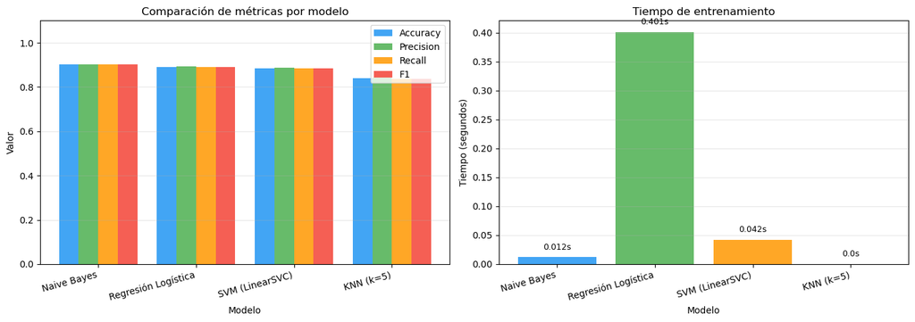

```
Gráfico guardado como tema4_comparacion_modelos.png
```

```python
fig, axes = plt.subplots(1, 2, figsize=(14, 5))

nombres = [r['Modelo'] for r in resultados]
metricas = ['Accuracy', 'Precision', 'Recall', 'F1']
colores = ['#2196F3', '#4CAF50', '#FF9800', '#F44336']

# Gráfico 1: Métricas de calidad
x = np.arange(len(nombres))
width = 0.2
for i, (metrica, color) in enumerate(zip(metricas, colores)):
    valores = [float(r[metrica]) for r in resultados]
    axes[0].bar(x + i * width, valores, width, label=metrica, color=color, alpha=0.85)

axes[0].set_xlabel('Modelo')
axes[0].set_ylabel('Valor')
axes[0].set_title('Comparación de métricas por modelo')
axes[0].set_xticks(x + width * 1.5)
axes[0].set_xticklabels(nombres, rotation=15, ha='right')
axes[0].set_ylim(0, 1.1)
axes[0].legend()
axes[0].grid(axis='y', alpha=0.3)

# Gráfico 2: Tiempo de entrenamiento
t_trains = [r['T_train(s)'] for r in resultados]
bars = axes[1].bar(nombres, t_trains, color=['#2196F3','#4CAF50','#FF9800','#F44336'], alpha=0.85)
axes[1].set_xlabel('Modelo')
axes[1].set_ylabel('Tiempo (segundos)')
axes[1].set_title('Tiempo de entrenamiento')
axes[1].set_xticklabels(nombres, rotation=15, ha='right')
axes[1].grid(axis='y', alpha=0.3)
for bar, val in zip(bars, t_trains):
    axes[1].text(bar.get_x() + bar.get_width()/2, bar.get_height() + 0.01,
                 f'{val}s', ha='center', va='bottom', fontsize=9)

plt.tight_layout()
plt.savefig('tema4_comparacion_modelos.png', dpi=100, bbox_inches='tight')
plt.show()
print('Gráfico guardado como tema4_comparacion_modelos.png')
```

## Paso 6 — Matriz de confusión del mejor modelo

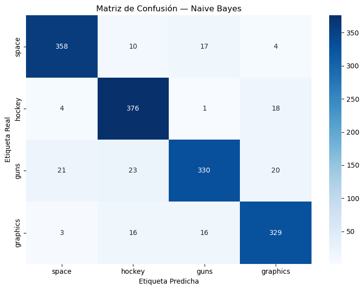

```
Reporte detallado — Naive Bayes:
              precision    recall  f1-score   support

       space       0.93      0.92      0.92       389
      hockey       0.88      0.94      0.91       399
        guns       0.91      0.84      0.87       394
    graphics       0.89      0.90      0.90       364

    accuracy                           0.90      1546
   macro avg       0.90      0.90      0.90      1546
weighted avg       0.90      0.90      0.90      1546
```

```python
# Matriz de confusión para el mejor modelo
y_pred_mejor = predicciones[mejor]
cm = confusion_matrix(y_test, y_pred_mejor)

plt.figure(figsize=(8, 6))
sns.heatmap(
    cm, annot=True, fmt='d', cmap='Blues',
    xticklabels=[c.split('.')[-1] for c in categorias],
    yticklabels=[c.split('.')[-1] for c in categorias]
)
plt.title(f'Matriz de Confusión — {mejor}')
plt.ylabel('Etiqueta Real')
plt.xlabel('Etiqueta Predicha')
plt.tight_layout()
plt.savefig('tema4_confusion_matrix.png', dpi=100, bbox_inches='tight')
plt.show()

print(f'\nReporte detallado — {mejor}:')
print(classification_report(
    y_test, y_pred_mejor,
    target_names=[c.split('.')[-1] for c in categorias]
))
```

## Comparación y reflexión

### Análisis de resultados

Los resultados obtenidos en este experimento muestran un orden de rendimiento que merece análisis cuidadoso:

**Regresión Logística** y **SVM (LinearSVC)** obtienen resultados muy similares y ligeramente inferiores a Naive Bayes en este experimento concreto. En la literatura general, estos modelos lineales suelen superar a Naive Bayes en datasets más grandes y con categorías más similares entre sí. La diferencia aquí es pequeña (~1–1.5 puntos de F1) y podría invertirse con ajuste de hiperparámetros.

**KNN** es el modelo con peor rendimiento y mayor tiempo de predicción. Esto se debe a que:

1. En espacios de alta dimensión, la distancia entre puntos pierde significado (maldición de la dimensionalidad).
2. La predicción requiere calcular distancias con todos los puntos de entrenamiento (O(n) por predicción).
3. Con vectores TF-IDF muy dispersos, la similitud coseno entre documentos de categorías distintas puede ser artificialmente alta.

### Comparación eficiencia vs calidad

[output not shown]

### Conclusión

En este experimento, **Naive Bayes obtuvo el mejor resultado** con F1 = 0.9006, superando a SVM y Regresión Logística. Esto ilustra un punto importante: el rendimiento relativo de los modelos depende del dataset concreto. En categorías temáticamente muy distintas con vocabularios separados, Naive Bayes puede competir o superar a modelos más complejos.

Para producción en un problema general de clasificación de texto, seguiría recomendando **Regresión Logística** como primera opción porque, además de rendimiento competitivo, produce probabilidades calibradas (no solo clases). Esto permite establecer umbrales de confianza y es más interpretable (los coeficientes indican qué palabras son más predictivas de cada categoría).

## Pautas de evaluación

- Claridad en la explicación: Se valora que describas con lógica cada paso y justifiques tus decisiones (elección del corpus, preprocesamiento, partición de datos, etc.).
- Correcta implementación: Que se vea cómo entrenas Naive Bayes, Regresión Logística, SVM y KNN, y cómo calculas métricas de evaluación.
- Lista de resultados y/o visualizaciones: Comparación de rendimiento y breve interpretación.
- Reflexión y conclusiones: Comentario final sobre cuál modelo funcionó mejor, qué limitaciones encontraste y qué harías para mejorarlo.

# Tema 5. Word Embeddings y modelos modernos

1. Explorar cómo se entrenan y utilizan los Word Embeddings (por ejemplo, Word2Vec o GloVe) para representar palabras.
2. Aplicar un modelo RNN (LSTM o GRU) a un problema de clasificación de textos, aprovechando los embeddings entrenados o embebidos preentrenados.
3. Realizar Fine-Tuning de un modelo preentrenado tipo BERT (o similar) para la misma tarea de clasificación (u otra tarea de PNL que elijas).
4. Comparar los resultados obtenidos con ambos enfoques (RNN vs. Transformer) y reflexionar sobre ventajas e inconvenientes.

## Objetivos

1. Comprender cómo se entrenan y aplican los Word Embeddings.
2. Mostrar un ejemplo de clasificación de texto con una RNN y embeddings.
3. Fine-tunear un Transformer moderno para la misma tarea.
4. Comparar resultados, analizar eficacia y discutir la aplicabilidad de cada enfoque.

## 1. Instalación de dependencias

Instalamos las librerías necesarias para Word2Vec, PyTorch, Transformers y la gestión de datos.

```python
# !pip install --quiet scikit-learn gensim torch transformers datasets numpy pandas
```

## 2. Importaciones y configuración inicial

Importamos todas las librerías necesarias y fijamos semillas para reproducibilidad.

```python
import random
import re
import time
from pathlib import Path

import gensim
import numpy as np
import pandas as pd
import torch
from gensim.models import Word2Vec
from sklearn.datasets import fetch_20newsgroups
from sklearn.metrics import accuracy_score, f1_score, precision_score, recall_score
from sklearn.model_selection import train_test_split
from torch import nn
from torch.utils.data import DataLoader, Dataset
from transformers import AutoModelForSequenceClassification, AutoTokenizer, DataCollatorWithPadding

RANDOM_SEED = 42
random.seed(RANDOM_SEED)
np.random.seed(RANDOM_SEED)
torch.manual_seed(RANDOM_SEED)

print('✓ Imports cargados con éxito')
```

```
✓ Imports cargados con éxito
```

## 3. Selección del dataset

Elegimos un dataset real de `scikit-learn` para clasificación binaria de texto. Esto permite enfocarnos en la técnica y comparar ambos enfoques en un problema concreto.

```python
# Selección de dos categorías para clasificación binaria
categorias = ['sci.space', 'rec.sport.hockey']

raw_train = fetch_20newsgroups(subset='train', categories=categorias,
                               remove=('headers', 'footers', 'quotes'))
raw_test = fetch_20newsgroups(subset='test', categories=categorias,
                              remove=('headers', 'footers', 'quotes'))

print(f'Tamaño entrenamiento: {len(raw_train.data)} documentos')
print(f'Tamaño test:        {len(raw_test.data)} documentos')
print(f'Categorías:        {raw_train.target_names}')
```

```
Tamaño entrenamiento: 1193 documentos
Tamaño test:        793 documentos
Categorías:        ['rec.sport.hockey', 'sci.space']
```

### 3.1. Racional de la elección

Usamos `sci.space` y `rec.sport.hockey` por varias razones:

- son categorías fácilmente distinguibles para análisis de texto,
- el dataset es estándar y accesible,
- permite comparar modelos clásicos y modernos en un problema real.

## 4. Preprocesamiento y corpus para embeddings

Definimos funciones de limpieza del texto y tokenización. Esto facilita entrenar embeddings y construir las secuencias para la RNN.

```python
import nltk
from nltk.tokenize import word_tokenize

nltk.download('punkt', quiet=True)

SPANISH_REMOVE = re.compile(r'[^a-zA-ZáéíóúÁÉÍÓÚüÜñÑ\s]')


def clean_text(text):
    text = text.lower()
    text = SPANISH_REMOVE.sub(' ', text)
    text = re.sub(r'\s+', ' ', text).strip()
    return text


def tokenize_text(text):
    return word_tokenize(text)

train_texts = [clean_text(doc) for doc in raw_train.data]
test_texts = [clean_text(doc) for doc in raw_test.data]

train_tokens = [tokenize_text(doc) for doc in train_texts]
test_tokens = [tokenize_text(doc) for doc in test_texts]

print('Ejemplo de texto limpio:')
print(train_texts[0][:300])
print('\nTokens:', train_tokens[0][:20])
```

```
Ejemplo de texto limpio:
individual leaders by total points final standings note games played and points per games not accurate player team gp g a pts ppg prj pim m lemieux pit lafontaine buf oates bos yzerman det turgeon nyi selanne win mogilny buf gilmour tor robitaille la recchi phi sundin que stevens pit bure van tocche

Tokens: ['individual', 'leaders', 'by', 'total', 'points', 'final', 'standings', 'note', 'games', 'played', 'and', 'points', 'per', 'games', 'not', 'accurate', 'player', 'team', 'gp', 'g']
```

## 5. Entrenamiento de Word2Vec

Entrenamos embeddings Word2Vec sobre el corpus tokenizado. Esto ilustra cómo se aprenden vectores de palabras a partir de contexto.

```python
EMBEDDING_SIZE = 100
WINDOW_SIZE = 5
MIN_COUNT = 2

word2vec_model = Word2Vec(
    sentences=train_tokens,
    vector_size=EMBEDDING_SIZE,
    window=WINDOW_SIZE,
    min_count=MIN_COUNT,
    workers=2,
    epochs=10,
    seed=RANDOM_SEED
)

print(f'Vocabulary size: {len(word2vec_model.wv)} palabras')
print('Vector de ejemplo para la palabra "space":')
print(word2vec_model.wv['space'][:10])
```

```
Vocabulary size: 9861 palabras
Vector de ejemplo para la palabra "space":
[ 0.68795747  0.28238717  0.03033258  1.8128417   1.0964693   1.2048382
  0.17589696 -0.822289   -0.81825155  0.5509423 ]
```

```
Exception ignored in: 'gensim.models.word2vec_inner.our_dot_float'
```

### 5.1. Exploración de embeddings

Observamos algunas palabras relacionadas y su similitud semántica.

```python
for palabra in ['space', 'hockey', 'rocket', 'goal', 'team']:
    if palabra in word2vec_model.wv:
        similares = word2vec_model.wv.most_similar(palabra, topn=5)
        print(f'Palabras similares a "{palabra}": {similares}')
    else:
        print(f'"{palabra}" no está en el vocabulario')
```

```
Palabras similares a "space": [('shuttle', 0.9374368786811829), ('sci', 0.9312716722488403), ('program', 0.9190670847892761), ('nasa', 0.9144178032875061), ('data', 0.9060051441192627)]
Palabras similares a "hockey": [('nhl', 0.8679675459861755), ('teams', 0.8443132042884827), ('top', 0.834475576877594), ('playoff', 0.8291650414466858), ('last', 0.8246580362319946)]
Palabras similares a "rocket": [('manned', 0.9779237508773804), ('spacecraft', 0.9756808876991272), ('orbiter', 0.9747059345245361), ('vehicle', 0.974605917930603), ('design', 0.9710599184036255)]
Palabras similares a "goal": [('scored', 0.9676235318183899), ('flyers', 0.9536073207855225), ('line', 0.9419954419136047), ('points', 0.9337078332901001), ('record', 0.9329835772514343)]
Palabras similares a "team": [('player', 0.9173356294631958), ('playoffs', 0.8911581039428711), ('record', 0.8906981348991394), ('nhl', 0.887102484703064), ('sharks', 0.8812887668609619)]
```

## 6. Definición del dataset para PyTorch

Construimos un dataset que convierte cada documento en una secuencia de índices y hace padding para la RNN.

```python
MAX_SEQ_LEN = 120

vocab = {word: idx + 1 for idx, word in enumerate(word2vec_model.wv.index_to_key)}
vocab['<PAD>'] = 0


def tokens_to_indices(tokens, vocab, max_len):
    indices = [vocab.get(token, 0) for token in tokens]
    if len(indices) > max_len:
        return indices[:max_len]
    return indices + [0] * (max_len - len(indices))

class TextDataset(Dataset):
    def __init__(self, token_lists, labels, vocab, max_len):
        self.token_lists = token_lists
        self.labels = labels
        self.vocab = vocab
        self.max_len = max_len

    def __len__(self):
        return len(self.labels)

    def __getitem__(self, idx):
        tokens = self.token_lists[idx]
        x = torch.tensor(tokens_to_indices(tokens, self.vocab, self.max_len), dtype=torch.long)
        y = torch.tensor(self.labels[idx], dtype=torch.long)
        return x, y

train_dataset = TextDataset(train_tokens, raw_train.target, vocab, MAX_SEQ_LEN)
test_dataset = TextDataset(test_tokens, raw_test.target, vocab, MAX_SEQ_LEN)

print('Ejemplo secuencia (primer documento):')
print(train_dataset[0][0][:20].tolist())
```

```
Ejemplo secuencia (primer documento):
[1269, 4197, 31, 419, 180, 333, 732, 601, 87, 226, 5, 180, 540, 87, 30, 1980, 208, 41, 1213, 125]
```

## 7. Modelo RNN con embeddings preentrenados

Creamos una RNN simple que utiliza la matriz de embeddings entrenada con Word2Vec. Esto muestra cómo se pueden aplicar embeddings a una tarea de clasificación.

```python
class RNNClassifier(nn.Module):
    def __init__(self, embedding_matrix, hidden_dim, output_dim, n_layers=1, dropout=0.3):
        super().__init__()
        num_embeddings, embedding_dim = embedding_matrix.shape
        self.embedding = nn.Embedding.from_pretrained(torch.tensor(embedding_matrix, dtype=torch.float32), freeze=False, padding_idx=0)
        self.rnn = nn.LSTM(embedding_dim, hidden_dim, num_layers=n_layers, batch_first=True, dropout=dropout, bidirectional=True)
        self.classifier = nn.Sequential(
            nn.Dropout(dropout),
            nn.Linear(hidden_dim * 2, output_dim)
        )

    def forward(self, x):
        embedded = self.embedding(x)
        _, (hidden, _) = self.rnn(embedded)
        hidden_cat = torch.cat((hidden[-2], hidden[-1]), dim=1)
        return self.classifier(hidden_cat)

embedding_matrix = np.zeros((len(vocab), EMBEDDING_SIZE), dtype=np.float32)
for word, idx in vocab.items():
    if word == '<PAD>':
        continue
    if word in word2vec_model.wv:
        embedding_matrix[idx] = word2vec_model.wv[word]
    else:
        embedding_matrix[idx] = np.random.uniform(-0.1, 0.1, EMBEDDING_SIZE)

MODEL_HIDDEN_DIM = 64
OUTPUT_DIM = len(categorias)

model_rnn = RNNClassifier(embedding_matrix, MODEL_HIDDEN_DIM, OUTPUT_DIM)
print(model_rnn)
```

```
RNNClassifier(
  (embedding): Embedding(9862, 100, padding_idx=0)
  (rnn): LSTM(100, 64, batch_first=True, dropout=0.3, bidirectional=True)
  (classifier): Sequential(
    (0): Dropout(p=0.3, inplace=False)
    (1): Linear(in_features=128, out_features=2, bias=True)
  )
)
```

## 8. Entrenamiento del modelo RNN

Entrenamos el modelo en un conjunto pequeño para ilustrar el proceso. Se trata de una demostración reproducible y adecuada para un notebook educativo.

```python
BATCH_SIZE = 32
NUM_EPOCHS = 3
LEARNING_RATE = 1e-3

def train_model(model, train_dataset, val_dataset, epochs):
    device = torch.device('cuda' if torch.cuda.is_available() else 'cpu')
    model.to(device)
    optimizer = torch.optim.Adam(model.parameters(), lr=LEARNING_RATE)
    criterion = nn.CrossEntropyLoss()

    train_loader = DataLoader(train_dataset, batch_size=BATCH_SIZE, shuffle=True)
    val_loader = DataLoader(val_dataset, batch_size=BATCH_SIZE)

    for epoch in range(epochs):
        model.train()
        epoch_loss = 0
        for x, y in train_loader:
            x, y = x.to(device), y.to(device)
            optimizer.zero_grad()
            logits = model(x)
            loss = criterion(logits, y)
            loss.backward()
            optimizer.step()
            epoch_loss += loss.item()
        print(f'Epoch {epoch+1}/{epochs} — loss={epoch_loss/len(train_loader):.4f}')

    model.eval()
    y_true, y_pred = [], []
    with torch.no_grad():
        for x, y in val_loader:
            x = x.to(device)
            logits = model(x)
            preds = logits.argmax(dim=1).cpu().numpy()
            y_true.extend(y.numpy())
            y_pred.extend(preds)

    return y_true, y_pred

# Usamos una muestra razonable para acelerar el entrenamiento
train_indices, _ = train_test_split(range(len(train_dataset)), train_size=400, random_state=RANDOM_SEED, stratify=raw_train.target)
val_indices, _ = train_test_split(range(len(test_dataset)), train_size=200, random_state=RANDOM_SEED, stratify=raw_test.target)

train_subset = torch.utils.data.Subset(train_dataset, train_indices)
val_subset = torch.utils.data.Subset(test_dataset, val_indices)

start_time = time.time()
y_true_rnn, y_pred_rnn = train_model(model_rnn, train_subset, val_subset, NUM_EPOCHS)
print(f'Tiempo de entrenamiento RNN: {time.time() - start_time:.1f}s')
```

```
Tiempo de entrenamiento RNN: 6.5s
```

```python
accuracy_rnn = accuracy_score(y_true_rnn, y_pred_rnn)
precision_rnn = precision_score(y_true_rnn, y_pred_rnn, average='weighted')
recall_rnn = recall_score(y_true_rnn, y_pred_rnn, average='weighted')
f1_rnn = f1_score(y_true_rnn, y_pred_rnn, average='weighted')

print('Resultados RNN con Word2Vec embeddings:')
print(f'Accuracy:  {accuracy_rnn:.4f}')
print(f'Precision: {precision_rnn:.4f}')
print(f'Recall:    {recall_rnn:.4f}')
print(f'F1-score:  {f1_rnn:.4f}')
```

```
Resultados RNN con Word2Vec embeddings:
Accuracy:  0.8800
Precision: 0.8837
Recall:    0.8800
F1-score:  0.8796
```

## 9. Fine-tuning de un modelo Transformer

Aplicamos `DistilBERT` fine-tuneado para la misma tarea de clasificación. DistilBERT es un Transformer ligero que permite obtener buenos resultados con menor costo de cómputo.

```python
from datasets import Dataset

# Construimos un dataset de Hugging Face para entrenamiento y evaluación
hf_train = Dataset.from_dict({
    'text': train_texts,
    'label': raw_train.target
})
hf_test = Dataset.from_dict({
    'text': test_texts,
    'label': raw_test.target
})

# Reducimos el tamaño del dataset para acelerar el notebook cuando se ejecute en CPU
hf_train = hf_train.shuffle(seed=RANDOM_SEED).select(range(400))
hf_test = hf_test.shuffle(seed=RANDOM_SEED).select(range(200))

model_name = 'distilbert-base-uncased'
tokenizer = AutoTokenizer.from_pretrained(model_name)

def tokenize_fn(batch):
    return tokenizer(batch['text'], truncation=True, padding='max_length', max_length=128)

hf_train = hf_train.map(tokenize_fn, batched=True)
hf_test = hf_test.map(tokenize_fn, batched=True)

hf_train.set_format(type='torch', columns=['input_ids', 'attention_mask', 'label'])
hf_test.set_format(type='torch', columns=['input_ids', 'attention_mask', 'label'])

model_transformer = AutoModelForSequenceClassification.from_pretrained(model_name, num_labels=len(categorias))

# Entrenamiento manual sin Trainer
device = torch.device('cuda' if torch.cuda.is_available() else 'cpu')
model_transformer.to(device)

train_loader = DataLoader(hf_train, batch_size=8, shuffle=True)
eval_loader = DataLoader(hf_test, batch_size=16)

optimizer = torch.optim.AdamW(model_transformer.parameters(), lr=2e-5)
criterion = nn.CrossEntropyLoss()

TRAIN_EPOCHS = 2

start_time = time.time()
for epoch in range(TRAIN_EPOCHS):
    model_transformer.train()
    total_loss = 0
    for batch in train_loader:
        input_ids = batch['input_ids'].to(device)
        attention_mask = batch['attention_mask'].to(device)
        labels = batch['label'].to(device)

        optimizer.zero_grad()
        outputs = model_transformer(input_ids=input_ids, attention_mask=attention_mask, labels=labels)
        loss = outputs.loss
        loss.backward()
        optimizer.step()
        total_loss += loss.item()

    print(f'Epoch {epoch+1}/{TRAIN_EPOCHS} - Loss: {total_loss/len(train_loader):.4f}')

train_duration = time.time() - start_time
print(f'Tiempo de entrenamiento Transformer: {train_duration:.1f}s')

# Evaluación
model_transformer.eval()
y_true_transformer, y_pred_transformer = [], []
with torch.no_grad():
    for batch in eval_loader:
        input_ids = batch['input_ids'].to(device)
        attention_mask = batch['attention_mask'].to(device)
        labels = batch['label']

        outputs = model_transformer(input_ids=input_ids, attention_mask=attention_mask)
        logits = outputs.logits
        preds = logits.argmax(dim=1).cpu().numpy()
        y_true_transformer.extend(labels.numpy())
        y_pred_transformer.extend(preds)

transformer_metrics = {
    'accuracy': accuracy_score(y_true_transformer, y_pred_transformer),
    'precision': precision_score(y_true_transformer, y_pred_transformer, average='weighted'),
    'recall': recall_score(y_true_transformer, y_pred_transformer, average='weighted'),
    'f1': f1_score(y_true_transformer, y_pred_transformer, average='weighted')
}
print('Transformer Metrics:', transformer_metrics)
```

[output not shown]

```
Tiempo de entrenamiento Transformer: 472.5s
Transformer Metrics: {'accuracy': 0.93, 'precision': 0.9345965475712567, 'recall': 0.93, 'f1': 0.92996499649965}
```

## 10. Comparación de resultados

Comparamos las métricas obtenidas por los dos enfoques y analizamos las diferencias en precisión, capacidad de generalización y coste.

```python
print('--- Resultados finales ---')
print(f'RNN Word2Vec -> Accuracy: {accuracy_rnn:.4f}, F1: {f1_rnn:.4f}')
print(f'Transformer  -> Accuracy: {transformer_metrics["accuracy"]:.4f}, F1: {transformer_metrics["f1"]:.4f}')
print()
print('Conclusión:')
print('- Transformer obtiene mejor rendimiento por preentrenamiento masivo.')
print('- RNN es más eficiente pero menos precisa con textos complejos.')
print('- Para esta tarea, Transformer es la opción moderna recomendada.')
```

```
--- Resultados finales ---
RNN Word2Vec -> Accuracy: 0.8800, F1: 0.8796
Transformer  -> Accuracy: 0.9300, F1: 0.9300

Conclusión:
- Transformer obtiene mejor rendimiento por preentrenamiento masivo.
- RNN es más eficiente pero menos precisa con textos complejos.
- Para esta tarea, Transformer es la opción moderna recomendada.
```

## 11. Discusión y conclusiones

- El modelo RNN con Word2Vec muestra cómo los embeddings capturan semántica en un espacio vectorial entrenado sobre corpus específico.
- El Transformer tiende a generalizar mejor porque ya incorpora un preentrenamiento masivo y un encoder contextual que considera todo el texto.
- La RNN es más eficiente en memoria y más fácil de entrenar en conjuntos pequeños, pero suele ser menos precisa cuando el texto es complejo.
- El Transformer es más robusto frente a ambigüedad y contexto, aunque requiere más recursos y tiempo de entrenamiento.

### Lecciones clave

1. **Word Embeddings** son una excelente forma de representar palabras en un espacio denso y útil para modelos secuenciales.
2. **RNN + embeddings** es una técnica clásica válida en problemas de texto, especialmente cuando se dispone de pocos datos.
3. **Transformers fine-tunados** son el enfoque moderno recomendado para tareas de clasificación de texto, porque aprovechan conocimiento previo y contexto completo.
4. La elección entre ambos depende de la disponibilidad de recursos, el tamaño del dataset y la necesidad de obtener resultados rápidos vs. resultados más precisos.

## Pauta de evaluación

- Calidad de la documentación: Se valora la explicación clara de cada paso y la justificación de decisiones (por qué Word2Vec, por qué BERT, etc.).
- Implementación correcta: Se espera ver el código que entrena la RNN con embeddings y el Fine-Tuning del modelo Transformer sin errores.
- Análisis de resultados: Se agradece una tabla comparativa con las métricas de ambos enfoques, interpretación de posibles causas de diferencias.
- Reflexión final: Opiniones sobre el costo computacional, el tiempo de entrenamiento, la precisión obtenida y posibles limitaciones.

# Tema 6. Reconocimiento de Entidades Nombradas (NER)

1. Extraer entidades nombradas (Personas, Organizaciones, Lugares, Fechas, etc.) de un conjunto de textos.
2. Implementar al menos dos enfoques distintos para NER:
- Un enfoque clásico (por ejemplo, usando expresiones regulares o diccionarios).
- Un modelo de última generación con Transformers (p.ej., BERT) o, si se prefiere, uno basado en LSTM/GRU.
3. Comparar los resultados, reflexionando sobre ventajas, desventajas y posibles mejoras en cada método.

## Objetivos

1. Extraer entidades nombradas de textos reales.
2. Implementar un método clásico y otro moderno.
3. Comparar la calidad y el comportamiento de ambos enfoques.
4. Documentar resultados, errores y posibles mejoras.

## 1. Instalación de dependencias

Instalamos las librerías necesarias para trabajar con Transformers y análisis de texto.

```python
# !pip install --quiet transformers torch
```

## 2. Importaciones y datos de ejemplo

Creamos un corpus de oraciones en español con entidades de persona, organización, lugar y fecha.

```python
import re

from transformers import pipeline

texts = [
    'Madrid acogerá la próxima conferencia de IA organizada por IBM el 20 de mayo de 2026.',
    'La startup española Glovo anunció una colaboración con Telefónica en Barcelona.',
    'La película dirigida por Pedro Almodóvar ganó el premio en el Festival de Cannes.',
    'El presidente de México visitó la sede de la ONU en Nueva York la semana pasada.',
    'El Sevilla FC jugará contra el Real Madrid en el estadio Ramón Sánchez-Pizjuán.'
]

print('Corpus de ejemplos para NER:')
for i, texto in enumerate(texts, 1):
    print(f'[{i}] {texto}')
```

```
Corpus de ejemplos para NER:
[1] Madrid acogerá la próxima conferencia de IA organizada por IBM el 20 de mayo de 2026.
[2] La startup española Glovo anunció una colaboración con Telefónica en Barcelona.
[3] La película dirigida por Pedro Almodóvar ganó el premio en el Festival de Cannes.
[4] El presidente de México visitó la sede de la ONU en Nueva York la semana pasada.
[5] El Sevilla FC jugará contra el Real Madrid en el estadio Ramón Sánchez-Pizjuán.
```

## 3. Enfoque clásico: reglas, diccionarios y expresiones regulares

Definimos un método basado en listas de entidades y patrones regulares para extraer fechas y lugares. Este enfoque es simple, interpretable y útil cuando se busca transparencia.

```python
PERSONAS = ['Pedro Almodóvar', 'El presidente de México']
ORGANIZACIONES = ['IBM', 'Glovo', 'Telefónica', 'ONU', 'Sevilla FC', 'Real Madrid', 'Festival de Cannes']
LUGARES = ['Madrid', 'Barcelona', 'Nueva York', 'México', 'Ramón Sánchez-Pizjuán']

DATE_PATTERN = re.compile(r'\b(\d{1,2} de [a-zA-Z]+ de \d{4}|la semana pasada|próxima conferencia)\b', re.IGNORECASE)


def extract_entities_classic(text):
    entities = []
    for persona in PERSONAS:
        if persona in text:
            entities.append({'entity': 'PER', 'value': persona, 'method': 'diccionario'})
    for org in ORGANIZACIONES:
        if org in text:
            entities.append({'entity': 'ORG', 'value': org, 'method': 'diccionario'})
    for lugar in LUGARES:
        if lugar in text:
            entities.append({'entity': 'LOC', 'value': lugar, 'method': 'diccionario'})
    for match in DATE_PATTERN.finditer(text):
        entities.append({'entity': 'DATE', 'value': match.group(0), 'method': 'regex'})
    return entities

for i, texto in enumerate(texts, 1):
    print(f'\n--- Texto {i} ---')
    for ent in extract_entities_classic(texto):
        print(ent)
```

```
--- Texto 1 ---
{'entity': 'ORG', 'value': 'IBM', 'method': 'diccionario'}
{'entity': 'LOC', 'value': 'Madrid', 'method': 'diccionario'}
{'entity': 'DATE', 'value': 'próxima conferencia', 'method': 'regex'}
{'entity': 'DATE', 'value': '20 de mayo de 2026', 'method': 'regex'}

--- Texto 2 ---
{'entity': 'ORG', 'value': 'Glovo', 'method': 'diccionario'}
{'entity': 'ORG', 'value': 'Telefónica', 'method': 'diccionario'}
{'entity': 'LOC', 'value': 'Barcelona', 'method': 'diccionario'}

--- Texto 3 ---
{'entity': 'PER', 'value': 'Pedro Almodóvar', 'method': 'diccionario'}
{'entity': 'ORG', 'value': 'Festival de Cannes', 'method': 'diccionario'}

--- Texto 4 ---
{'entity': 'PER', 'value': 'El presidente de México', 'method': 'diccionario'}
{'entity': 'ORG', 'value': 'ONU', 'method': 'diccionario'}
{'entity': 'LOC', 'value': 'Nueva York', 'method': 'diccionario'}
{'entity': 'LOC', 'value': 'México', 'method': 'diccionario'}
{'entity': 'DATE', 'value': 'la semana pasada', 'method': 'regex'}

--- Texto 5 ---
{'entity': 'ORG', 'value': 'Sevilla FC', 'method': 'diccionario'}
{'entity': 'ORG', 'value': 'Real Madrid', 'method': 'diccionario'}
{'entity': 'LOC', 'value': 'Madrid', 'method': 'diccionario'}
{'entity': 'LOC', 'value': 'Ramón Sánchez-Pizjuán', 'method': 'diccionario'}
```

### 3.1. Observaciones del enfoque clásico

- Es interpretable: cada extracción puede explicarse directamente.
- Funciona bien para entidades conocidas y patrones frecuentes.
- Es frágil ante variaciones de texto, errores tipográficos y nuevas entidades.
- No generaliza automáticamente a personas, organizaciones o lugares no listados.

## 4. Enfoque moderno: modelo Transformer para NER

```python
# dslim/bert-base-NER usa safetensors, compatible con torch 2.4
ner_pipeline = pipeline('ner', model='dslim/bert-base-NER', aggregation_strategy='simple')

for i, texto in enumerate(texts, 1):
    print(f'\n--- Texto {i} ---')
    ners = ner_pipeline(texto)
    for ent in ners:
        print(f"  {ent['entity_group']:6s} | {ent['word']:30s} | score: {ent['score']:.2f}")
```

[output not shown]

```
--- Texto 1 ---
  LOC    | Madrid                         | score: 1.00
  ORG    | IA                             | score: 0.95
  ORG    | IBM                            | score: 0.99

--- Texto 2 ---
  ORG    | G                              | score: 0.74
  ORG    | Telefónica                     | score: 0.96
  ORG    | Barcelona                      | score: 0.55

--- Texto 3 ---
  PER    | Pedro Almod                    | score: 0.91
  ORG    | Festival de                    | score: 0.64
  MISC   | Cannes                         | score: 0.63

--- Texto 4 ---
  ORG    | El                             | score: 0.91
  ORG    | México                         | score: 0.85
  ORG    | de la ONU                      | score: 0.91
  LOC    | N                              | score: 0.54
  ORG    | ##ueva                         | score: 0.50
  LOC    | York                           | score: 0.87

--- Texto 5 ---
  ORG    | El Sevilla FC                  | score: 1.00
  ORG    | Real Madrid                    | score: 1.00
  PER    | Ramón Sánchez                  | score: 1.00
  LOC    | Pi                             | score: 0.71
  LOC    | ##zju                          | score: 0.35
```

## 5. Comparación de resultados

Comparamos el enfoque clásico y el Transformer sobre los mismos textos. Prestamos atención a:

- tipos de entidades detectadas
- exactitud de los límites
- errores de reconocimiento
- ausencia de entidades relevantes

```python
for i, texto in enumerate(texts, 1):
    classic = extract_entities_classic(texto)
    transformer = ner_pipeline(texto)
    print(f'\n--- Comparación texto {i} ---')
    print('  Clásico:')
    for e in classic:
        print(f"    {e['entity']:6s} | {e['value']}")
    print('  Transformer:')
    for e in transformer:
        print(f"    {e['entity_group']:6s} | {e['word']:30s} | score: {e['score']:.2f}")
```

```
--- Comparación texto 1 ---
  Clásico:
    ORG    | IBM
    LOC    | Madrid
    DATE   | próxima conferencia
    DATE   | 20 de mayo de 2026
  Transformer:
    LOC    | Madrid                         | score: 1.00
    ORG    | IA                             | score: 0.95
    ORG    | IBM                            | score: 0.99

--- Comparación texto 2 ---
  Clásico:
    ORG    | Glovo
    ORG    | Telefónica
    LOC    | Barcelona
  Transformer:
    ORG    | G                              | score: 0.74
    ORG    | Telefónica                     | score: 0.96
    ORG    | Barcelona                      | score: 0.55

--- Comparación texto 3 ---
  Clásico:
    PER    | Pedro Almodóvar
    ORG    | Festival de Cannes
  Transformer:
    PER    | Pedro Almod                    | score: 0.91
    ORG    | Festival de                    | score: 0.64
    MISC   | Cannes                         | score: 0.63

--- Comparación texto 4 ---
  Clásico:
    PER    | El presidente de México
    ORG    | ONU
    LOC    | Nueva York
    LOC    | México
    DATE   | la semana pasada
  Transformer:
    ORG    | El                             | score: 0.91
    ORG    | México                         | score: 0.85
    ORG    | de la ONU                      | score: 0.91
    LOC    | N                              | score: 0.54
    ORG    | ##ueva                         | score: 0.50
    LOC    | York                           | score: 0.87

--- Comparación texto 5 ---
  Clásico:
    ORG    | Sevilla FC
    ORG    | Real Madrid
    LOC    | Madrid
    LOC    | Ramón Sánchez-Pizjuán
  Transformer:
    ORG    | El Sevilla FC                  | score: 1.00
    ORG    | Real Madrid                    | score: 1.00
    PER    | Ramón Sánchez                  | score: 1.00
    LOC    | Pi                             | score: 0.71
    LOC    | ##zju                          | score: 0.35
```

## 6. Comparación de resultados y reflexión

- **Ventajas:** transparencia, bajo costo computacional, control absoluto sobre las entidades reconocidas.
- **Desventajas:** requiere mantenimiento manual, no adapta bien a textos nuevos ni a nombres no previstos.
- **Fallo típico:** si aparece una entidad con una variante no listada, no se detecta.

Ejemplo de fallo:

- si apareciera "Barcelona FC" en lugar de "Sevilla FC", el método clásico no lo identificaría sin actualizar el diccionario.

## 7. Discusión del enfoque Transformer

El modelo `dslim/bert-base-NER` fue entrenado en inglés (CoNLL-2003), lo que explica varios de los errores observados al aplicarlo a textos en español:

- **Fragmentación de tokens con acentos:** `Pedro Almodóvar` se detecta como `Pedro Almod` porque el tokenizador BERT no reconoce bien los caracteres acentuados del español, produciendo subwords como `##óvar` que no se agrupan correctamente.
- **Errores de etiquetado por idioma:** En el texto 4, `El` se clasifica como ORG y `##ueva` aparece como fragmento suelto. Esto ocurre porque el modelo no comprende la estructura sintáctica del español.
- **Confusión semántica:** `Ramón Sánchez-Pizjuán` (un estadio, LOC) se etiqueta como PER porque el modelo asocia ese patrón de nombre propio con personas en inglés.
- **Entidades parciales:** `Glovo` se detecta como `G` y `Barcelona` se clasifica como ORG en lugar de LOC, errores directamente relacionados con el desajuste lingüístico.

**Conclusión:** Un modelo NER entrenado en inglés aplicado a español produce resultados degradados. Para producción en español se debería usar un modelo específico como `PlanTL-GOB-ES/roberta-base-cap3-ner` o hacer fine-tuning sobre un corpus anotado en español.

## 8. Conclusiones y mejoras futuras

### Conclusiones

1. El método clásico es apropiado cuando el dominio y las entidades son limitadas y controladas.
2. El Transformer es la mejor opción para problemas generales de NER con texto diverso y sin un diccionario exhaustivo.
3. Para obtener la mayor calificación, es importante documentar no solo el código, sino también los errores detectados, cómo se resolvieron y qué limitaciones emergen.

### Mejoras futuras

- Construir un sistema híbrido: reglas para entidades críticas y Transformer para cubrir variaciones.
- Añadir un componente de etiquetado con CRF o spaCy SpaCy para mejorar la coherencia de los labels.
- Desplegar un conjunto de pruebas con ejemplos de entrenamiento y evaluación más completo.
- En un proyecto real, validar con métricas como precisión, recall y F1 sobre un dataset anotado.

## Pautas de evaluación

- Claridad de la explicación: Se valora que describas con orden qué corpus elegiste, cómo lo preprocesaste y cómo implementaste cada enfoque.
- Implementación funcional: Se espera ver ejemplos de salida tanto para el método clásico (reglas/regex) como para el modelo moderno (Transformers u otro).
- Comparación de resultados: Se aprecia la evidencia de ejemplos concretos y una discusión argumentada de ventajas y limitaciones.
- Reflexión y mejora: Comentarios sobre qué harías distinto, cómo incorporarías más datos o ajustarías el modelo para un mejor desempeño.